# Lab10: Regressão Linear Múltipla

## Introdução

Lembre-se de que exploramos a regressão linear simples examinando dados de beisebol da temporada de 2011 da *Major League Baseball* (MLB). Também usaremos esses dados para explorar a regressão múltipla. Nossa inspiração para explorar esses dados vem do filme Moneyball , que enfocou a “busca pelo segredo do sucesso no beisebol”. Ele segue uma equipe de baixo orçamento, o Oakland Athletics, que acreditava que estatísticas subutilizadas, como a capacidade de um jogador chegar à base, predizem melhor a capacidade de marcar pontos do que estatísticas típicas como *home runs*, *RBIs* (corridas impulsionadas) e média de rebatidas. Conseguir jogadores que se destacassem nessas estatísticas pouco aproveitadas acabou sendo muito mais acessível para o time.

Neste laboratório, veremos os dados de todos os 30 times da Liga Principal de Beisebol e examinaremos a relação linear entre as pontos marcados em uma temporada e várias estatísticas de outros jogadores. Nosso objetivo será encontrar o modelo que melhor prevê os pontos de uma equipe em uma temporada. Também pretendemos encontrar o modelo que melhor prevê o total de vitórias de uma equipe em uma temporada. O primeiro modelo nos diria em quais estatísticas do jogador devemos prestar atenção se quisermos obter pontos e o segundo modelo indicaria quais estatísticas do jogador devemos utilizar quando desejamos obter vitórias.

```r
library(ggplot2)
library(plyr)
library(tidyr)
library(dplyr)
library(DescTools)
library(htmltools)
library(knitr)
library(rmarkdown)
library(combinat)
library(kableExtra) #Para gerar tabelas com um layout agradável
library(leaps) #Para selecionar variaveis numa regressao multipla usando o adjr2
library(olsrr) #Para selecionar variaveis numa regressao multipla usando o p-valor da ANOVA
```

## Conteúdos abordados neste laboratório

- Regressão Linear Múltipla
- Otimização
- Intervalos de Confiança

## Os dados

Vamos carregar os dados para a temporada de 2011:

```r
download.file("http://www.openintro.org/stat/data/mlb11.RData", destfile = "mlb11.RData")
load("mlb11.RData")
```

Além dos pontos marcados (`runs`), este conjunto de dados contém sete variáveis tradicionalmente utilizadas: vez ao taco (`at_bats`), rebatidas (`hits`), rebatidas para fora do campo (`homeruns`), média de rebatidas (`bat_avg`), eliminações (`strikeouts`), bases roubadas (`stolen_bases`), e vitórias (`wins`). Também foram incluídas três novas variáveis: percentual de alcance de base (`new_onbase`), percentual de potência (`new_slug`), e alcance de base mais potência (`new_obs`). Para a primeira parte da análise vamos considerar as sete variáveis tradicionais. Ao final do laboratório, você trabalhará sozinho com as variáveis mais recentes.

Também gostaríamos de modificar os dados para facilitar o trabalho durante a seleção do modelo. Removemos a variável `team` do conjunto de dados e armazenamos a versão atualizada em `mlb11_wins`.

```r
mlb11_wins = mlb11 %>%
  select(-team)
```

Como `wins` não é uma estatística a nível de jogador - pelo menos para não arremessadores - não queremos usá-la ao prever `runs`. Portanto, vamos criar outro conjunto de dados modificado para utilizar ao tentar encontrar o melhor modelo para prever o número total de pontos marcados por uma equipe durante uma temporada. O inverso não é um problema ao tentar prever o número de vitórias de um time em uma temporada - `runs` pode ser usado para prever `wins`.

```r
mlb11_runs = mlb11_wins %>%
  select(-wins)
```

Conforme discutido em aula, há muitas maneiras de selecionar o modelo. Veremos a seguir alguns métodos de seleção.

## A busca pelo melhor modelo

Conforme discutido em aula, há muitas maneiras de selecionar o modelo. Veremos os métodos de seleção direto e reverso, os quais utilizam critérios diferentes ($R_{adj}^2$, p-valor ou AIC).

### Previsão dos pontos marcados usando seleção reversa

O primeiro passo na seleção reversa é definir um modelo completo. Como criamos um conjunto de dados modificado para prever os pontos marcados, podemos usar um atalho, `runs ~ .`, para dizer ao R para usar todas as variáveis restantes para prever pontos.

```r
runs_full = lm(runs ~ ., data = mlb11_runs)
summary(runs_full)
```

```
##
## Call:
## lm(formula = runs ~ ., data = mlb11_runs)
##
## Residuals:
##     Min      1Q  Median      3Q     Max
## -40.062 -10.675   0.089   9.404  28.293
##
## Coefficients:
##                Estimate Std. Error t value Pr(>|t|)
## (Intercept)   2.448e+03  2.775e+03   0.882   0.3882
## at_bats      -5.564e-01  4.975e-01  -1.118   0.2766
## hits          2.578e+00  1.934e+00   1.333   0.1975
## homeruns      3.937e-01  4.537e-01   0.868   0.3957
## bat_avg      -1.506e+04  1.081e+04  -1.393   0.1790
## strikeouts   -2.835e-02  4.828e-02  -0.587   0.5637
## stolen_bases  3.209e-01  1.343e-01   2.389   0.0269 *
## new_onbase   -3.551e+03  6.888e+03  -0.515   0.6119
## new_slug     -6.049e+03  6.947e+03  -0.871   0.3942
## new_obs       6.972e+03  6.850e+03   1.018   0.3209
## ---
## Signif. codes:  0 '***' 0.001 '**' 0.01 '*' 0.05 '.' 0.1 ' ' 1
##
## Residual standard error: 19.1 on 20 degrees of freedom
## Multiple R-squared:  0.963,  Adjusted R-squared:  0.9464
## F-statistic: 57.86 on 9 and 20 DF,  p-value: 2.327e-12
```

> Exercício 1: Quantas variáveis estão sendo usadas para prever `runs` no modelo completo? Quantos parâmetros estão sendo estimados no modelo completo? Quantos dos parâmetros são significativamente diferentes de 0 no nível 0,05? qual é o $R^2_{adj}$ do modelo completo?

Conforme a saída do último trecho de código, 9 variáveis estão sendo consideradas no modelo como preditoras de `runs`, ao passo que 10 parâmetros estão sendo estimados, já que o modelo linear envolve também um termo constante (intercepto).

De acordo com o modelo ajustado, apenas um parâmetro é significativo no nível de 0,05, que é o coeficiente do termo `stolen_bases`.

O $R^2_{adj}$ do modelo é igual a 0,9464 e, conforme já estudado no livro-texto, é um indicador da qualidade do ajuste, também conhecido como *coeficiente de explicação* do modelo, e nos mostra a proporção da variância na variável resposta que é explicada pelas variáveis independentes. Aqui, é importante fazer uma observação quanto à diferença entre o $R^2$ e o $R^2_{adj}$.

Agora que temos um modelo completo definido, podemos fazer a seleção reversa do modelo. A função `step()` torna extremamente fácil usar o AIC (Akiake’s Information Criterion) para seleção de modelo. Semelhantemente ao $R^2_{adj}$, o AIC aplica uma penalidade aos modelos que usam mais variáveis preditoras.

Usaremos o trecho de código a seguir para determinar o melhor modelo para prever os pontos de uma equipe em uma temporada usando seleção regressiva com AIC como critério (observe que um AIC mais baixo indica um modelo melhor).

```r
runs_backAIC = step(runs_full, direction = "backward")
```

```
## Start:  AIC=184.82
## runs ~ at_bats + hits + homeruns + bat_avg + strikeouts + stolen_bases +
##     new_onbase + new_slug + new_obs
##
##                Df Sum of Sq    RSS    AIC
## - new_onbase    1     96.94 7394.1 183.22
## - strikeouts    1    125.80 7423.0 183.33
## - homeruns      1    274.82 7572.0 183.93
## - new_slug      1    276.65 7573.8 183.94
## - new_obs       1    377.98 7675.1 184.34
## - at_bats       1    456.40 7753.6 184.64
## <none>                      7297.2 184.82
## - hits          1    648.26 7945.4 185.38
## - bat_avg       1    707.75 8004.9 185.60
## - stolen_bases  1   2081.88 9379.0 190.35
##
## Step:  AIC=183.22
## runs ~ at_bats + hits + homeruns + bat_avg + strikeouts + stolen_bases +
##     new_slug + new_obs
##
##                Df Sum of Sq     RSS    AIC
## - strikeouts    1     140.1  7534.2 181.78
## - homeruns      1     311.1  7705.2 182.45
## <none>                       7394.1 183.22
## - at_bats       1     593.0  7987.1 183.53
## - hits          1     803.8  8197.9 184.31
## - bat_avg       1     882.2  8276.3 184.60
## - new_slug      1    1521.2  8915.3 186.83
## - stolen_bases  1    2170.0  9564.1 188.94
## - new_obs       1    8796.5 16190.5 204.73
##
## Step:  AIC=181.78
## runs ~ at_bats + hits + homeruns + bat_avg + stolen_bases + new_slug +
##     new_obs
##
##                Df Sum of Sq     RSS    AIC
## - homeruns      1     418.9  7953.1 181.40
## - at_bats       1     481.2  8015.4 181.64
## <none>                       7534.2 181.78
## - hits          1     677.0  8211.2 182.36
```

[output cut: 12 more lines]

```
## - bat_avg       1     591.4  8544.5 181.56
## - new_slug      1    1324.1  9277.2 184.02
## - stolen_bases  1    1864.5  9817.6 185.72
## - new_obs       1    8516.1 16469.2 201.24
##
## Step:  AIC=180.46
## runs ~ hits + bat_avg + stolen_bases + new_slug + new_obs
##
##                Df Sum of Sq     RSS    AIC
## <none>                       8236.9 180.46
## - hits          1     925.4  9162.4 181.65
## - new_slug      1    1220.0  9456.9 182.60
## - bat_avg       1    1387.7  9624.6 183.13
## - stolen_bases  1    1808.0 10044.9 184.41
## - new_obs       1    8324.6 16561.5 199.41
```

```r
summary(runs_backAIC)
```

```
##
## Call:
## lm(formula = runs ~ hits + bat_avg + stolen_bases + new_slug +
##     new_obs, data = mlb11_runs)
##
## Residuals:
##     Min      1Q  Median      3Q     Max
## -47.974 -10.020  -2.483  14.455  35.314
##
## Coefficients:
##                Estimate Std. Error t value Pr(>|t|)
## (Intercept)   -685.4474   116.3816  -5.890 4.47e-06 ***
## hits             0.4367     0.2659   1.642   0.1136
## bat_avg      -3986.8871  1982.7086  -2.011   0.0557 .
## stolen_bases     0.2704     0.1178   2.295   0.0308 *
## new_slug     -1606.1502   851.8902  -1.885   0.0715 .
## new_obs       3325.3137   675.1944   4.925 5.03e-05 ***
## ---
## Signif. codes:  0 '***' 0.001 '**' 0.01 '*' 0.05 '.' 0.1 ' ' 1
##
## Residual standard error: 18.53 on 24 degrees of freedom
## Multiple R-squared:  0.9582, Adjusted R-squared:  0.9495
## F-statistic: 110.2 on 5 and 24 DF,  p-value: 9.595e-16
```

> Exercício 2: Quantos passos a seleção reversa usando AIC realizou antes de selecionar um modelo? Qual variável foi a primeira a ser removida? Quais variáveis acabaram no modelo final? Quantos parâmetros estão sendo estimados neste modelo final? Quantos dos parâmetros neste modelo final são significativamente diferentes de 0 no nível 0,05? Este modelo final tem um maior $R^2_{adj}$ do que o modelo completo para `runs`?

Conforme a saída do código acima, vemos que foram executados 4 passos até chegar-se no modelo supostamente mais adequado. A primeira variável removida foi `new_onbase`, ao passo que no modelo final restaram 5 das 9 variáveis. Como no modelo linear geralmente existe o termo `intercept`, 6 parâmetros estão sendo estimados no modelo resultante. Contudo, apenas 3 dos 6 parâmetros restantes são significativamente diferentes de zero no nível de 0,05.

O modelo resultante após a aplicação do AIC tem um $R^2_{adj}$ ligeiramente maior do que o modelo completo.

Agora, em vez de AIC, vamos usar o valor de $R^2_{adj}$ como nosso critério ao conduzir a seleção reversa. Lembre-se de que um valor mais alto de $R^2_{adj}$ indica um modelo melhor. Assim, começaremos com o modelo completo e, a cada passo, retiraremos uma variável do modelo.

```r
# Step 1
df1 = data.frame(
  modelo = c("completo", "-at_bats", "-hits", "-homeruns", "-bat_avg", "-strikeouts", "-stolen_bases", "-new_onbase", "-new_slug", "-new_obs"),
  adj_rsq = c(
    summary(lm(runs ~ . , mlb11_runs))$adj.r,
    summary(lm(runs ~ . - at_bats, mlb11_runs))$adj.r,
    summary(lm(runs ~ . - hits, mlb11_runs))$adj.r,
    summary(lm(runs ~ . - homeruns, mlb11_runs))$adj.r,
    summary(lm(runs ~ . - bat_avg, mlb11_runs))$adj.r,
    summary(lm(runs ~ . - strikeouts, mlb11_runs))$adj.r,
    summary(lm(runs ~ . - stolen_bases, mlb11_runs))$adj.r,
    summary(lm(runs ~ . - new_onbase, mlb11_runs))$adj.r,
    summary(lm(runs ~ . - new_slug, mlb11_runs))$adj.r,
    summary(lm(runs ~ . - new_obs, mlb11_runs))$adj.r
  )
)


df1 %>%
  kable() %>%
  kable_styling(
    full_width = F,
    bootstrap_options = c("striped", "hover", "condensed",
                          "responsive")
  ) %>%
  row_spec(
    which(df1$adj_rsq == max(
      c(
        summary(lm(runs ~ . , mlb11_runs))$adj.r,
        summary(lm(runs ~ . - at_bats, mlb11_runs))$adj.r,
        summary(lm(runs ~ . - hits, mlb11_runs))$adj.r,
        summary(lm(runs ~ . - homeruns, mlb11_runs))$adj.r,
        summary(lm(runs ~ . - bat_avg, mlb11_runs))$adj.r,
        summary(lm(runs ~ . - strikeouts, mlb11_runs))$adj.r,
        summary(lm(runs ~ . - stolen_bases, mlb11_runs))$adj.r,
        summary(lm(runs ~ . - new_onbase, mlb11_runs))$adj.r,
        summary(lm(runs ~ . - new_slug, mlb11_runs))$adj.r,
        summary(lm(runs ~ . - new_obs, mlb11_runs))$adj.r
        )
      )
      ),
    bold = T,
    color = "white",
    background = "green"
      )
```

| modelo | adj_rsq |
| --- | --- |
| completo | 0.9463665 |
| -at_bats | 0.9457257 |
| -hits | 0.9443828 |
| -homeruns | 0.9469968 |
| -bat_avg | 0.9439663 |
| -strikeouts | 0.9480400 |
| -stolen_bases | 0.9343475 |
| -new_onbase | 0.9482420 |
| -new_slug | 0.9469840 |
| -new_obs | 0.9462747 |

Uma vez que o modelo que removeu `new_onbase` tem o maior $R^2_{adj}$, passamos para a etapa 2 usando esse modelo e continuamos removendo uma variável por vez e calculamos o novo $R^2_{adj}$ para cada modelo.

```r
# Step 2
df1 = data.frame(
  modelo = c("-new_onbase", "-new_onbase-at_bats", "-new_onbase-hits", "-new_onbase-homeruns", "-new_onbase-bat_avg", "-new_onbase-strikeouts", "-new_onbase-stolen_bases", "-new_onbase-new_slug", "-new_onbase-new_obs"),
  adj_rsq = c(
    summary(lm(runs ~ . - new_onbase, mlb11_runs))$adj.r,
    summary(lm(runs ~ . - new_onbase - at_bats, mlb11_runs))$adj.r,
    summary(lm(runs ~ . - new_onbase - hits, mlb11_runs))$adj.r,
    summary(lm(runs ~ . - new_onbase - homeruns, mlb11_runs))$adj.r,
    summary(lm(runs ~ . - new_onbase - bat_avg, mlb11_runs))$adj.r,
    summary(lm(runs ~ . - new_onbase - strikeouts, mlb11_runs))$adj.r,
    summary(lm(runs ~ . - new_onbase - stolen_bases, mlb11_runs))$adj.r,
    summary(lm(runs ~ . - new_onbase - new_slug, mlb11_runs))$adj.r,
    summary(lm(runs ~ . - new_onbase - new_obs, mlb11_runs))$adj.r
  )
)


df1 %>%
  kable() %>%
  kable_styling(
    full_width = F,
    bootstrap_options = c("striped", "hover", "condensed",
                          "responsive")
  ) %>%
  row_spec(
    which(df1$adj_rsq == max(
      c(
        summary(lm(runs ~ . - new_onbase, mlb11_runs))$adj.r,
        summary(lm(runs ~ . - new_onbase - at_bats, mlb11_runs))$adj.r,
        summary(lm(runs ~ . - new_onbase - hits, mlb11_runs))$adj.r,
        summary(lm(runs ~ . - new_onbase - homeruns, mlb11_runs))$adj.r,
        summary(lm(runs ~ . - new_onbase - bat_avg, mlb11_runs))$adj.r,
        summary(lm(runs ~ . - new_onbase - strikeouts, mlb11_runs))$adj.r,
        summary(lm(runs ~ . - new_onbase - stolen_bases, mlb11_runs))$adj.r,
        summary(lm(runs ~ . - new_onbase - new_slug, mlb11_runs))$adj.r,
        summary(lm(runs ~ . - new_onbase - new_obs, mlb11_runs))$adj.r
        )
      )
      ),
    bold = T,
    color = "white",
    background = "green"
      )
```

| modelo | adj_rsq |
| --- | --- |
| -new_onbase | 0.9482420 |
| -new_onbase-at_bats | 0.9466321 |
| -new_onbase-hits | 0.9452235 |
| -new_onbase-homeruns | 0.9485156 |
| -new_onbase-bat_avg | 0.9447001 |
| -new_onbase-strikeouts | 0.9496586 |
| -new_onbase-stolen_bases | 0.9360952 |
| -new_onbase-new_slug | 0.9404302 |
| -new_onbase-new_obs | 0.8918190 |

Como o modelo que apresenta o maior $R^2_{adj}$ na etapa 2 é aquele que removeu a variável `strikeouts`, passamos para a etapa 3 usando o modelo que agora tem ambos `new_onbase` e `strikeouts` removidos e continuamos removendo uma variável por vez e calculando o novo valor $R^2_{adj}$ para cada modelo.

```r
# Step 3
df1 = data.frame(
  modelo = c("-new_onbase-strikeouts", "-new_onbase-strikeouts-at_bats", "-new_onbase-strikeouts-hits", "-new_onbase-strikeouts-homeruns", "-new_onbase-strikeouts-bat_avg", "-new_onbase-strikeouts-stolen_bases", "-new_onbase-strikeouts-new_slug", "-new_onbase-strikeouts-new_obs"),
  adj_rsq = c(
    summary(lm(runs ~ . - new_onbase - strikeouts, mlb11_runs))$adj.r,
    summary(lm(runs ~ . - new_onbase - strikeouts - at_bats, mlb11_runs))$adj.r,
    summary(lm(runs ~ . - new_onbase - strikeouts - hits, mlb11_runs))$adj.r,
    summary(lm(runs ~ . - new_onbase - strikeouts - homeruns, mlb11_runs))$adj.r,
    summary(lm(runs ~ . - new_onbase - strikeouts - bat_avg, mlb11_runs))$adj.r,
    summary(lm(runs ~ . - new_onbase - strikeouts - stolen_bases, mlb11_runs))$adj.r,
    summary(lm(runs ~ . - new_onbase - strikeouts - new_slug, mlb11_runs))$adj.r,
    summary(lm(runs ~ . - new_onbase - strikeouts - new_obs, mlb11_runs))$adj.r
  )
)

df1 %>%
  kable() %>%
  kable_styling(
    full_width = F,
    bootstrap_options = c("striped", "hover", "condensed",
                          "responsive")
  ) %>%
  row_spec(
    which(df1$adj_rsq == max(
      c(
        summary(lm(runs ~ . - new_onbase - strikeouts, mlb11_runs))$adj.r,
        summary(lm(runs ~ . - new_onbase - strikeouts - at_bats, mlb11_runs))$adj.r,
        summary(lm(runs ~ . - new_onbase - strikeouts - hits, mlb11_runs))$adj.r,
        summary(lm(runs ~ . - new_onbase - strikeouts - homeruns, mlb11_runs))$adj.r,
        summary(lm(runs ~ . - new_onbase - strikeouts - bat_avg, mlb11_runs))$adj.r,
        summary(lm(runs ~ . - new_onbase - strikeouts - stolen_bases, mlb11_runs))$adj.r,
        summary(lm(runs ~ . - new_onbase - strikeouts - new_slug, mlb11_runs))$adj.r,
        summary(lm(runs ~ . - new_onbase - strikeouts - new_obs, mlb11_runs))$adj.r
        )
      )
      ),
    bold = T,
    color = "white",
    background = "green"
      )
```

| modelo | adj_rsq |
| --- | --- |
| -new_onbase-strikeouts | 0.9496586 |
| -new_onbase-strikeouts-at_bats | 0.9487720 |
| -new_onbase-strikeouts-hits | 0.9475203 |
| -new_onbase-strikeouts-homeruns | 0.9491698 |
| -new_onbase-strikeouts-bat_avg | 0.9470928 |
| -new_onbase-strikeouts-stolen_bases | 0.9372583 |
| -new_onbase-strikeouts-new_slug | 0.9414378 |
| -new_onbase-strikeouts-new_obs | 0.8965225 |

Como nenhum dos modelos que retira mais uma variável adicional do modelo que já exclui ambas `new_onbase` e `strikeouts` tem maior $R^2_{adj}$, paramos o processo e agora temos um modelo final. No código abaixo, armazenamos o modelo final e vemos um resumo dele.

```r
runs_backADJr = update(runs_full, ~ . - new_onbase - strikeouts)
summary(runs_backADJr)
```

```
##
## Call:
## lm(formula = runs ~ at_bats + hits + homeruns + bat_avg + stolen_bases +
##     new_slug + new_obs, data = mlb11_runs)
##
## Residuals:
##     Min      1Q  Median      3Q     Max
## -40.735  -8.985  -1.154   9.812  30.657
##
## Coefficients:
##                Estimate Std. Error t value Pr(>|t|)
## (Intercept)   2.241e+03  2.478e+03   0.904   0.3755
## at_bats      -5.338e-01  4.503e-01  -1.185   0.2485
## hits          2.455e+00  1.746e+00   1.406   0.1737
## homeruns      4.737e-01  4.283e-01   1.106   0.2807
## bat_avg      -1.403e+04  9.519e+03  -1.474   0.1547
## stolen_bases  3.337e-01  1.292e-01   2.582   0.0170 *
## new_slug     -2.601e+03  1.192e+03  -2.181   0.0402 *
## new_obs       3.404e+03  6.771e+02   5.028 4.93e-05 ***
## ---
## Signif. codes:  0 '***' 0.001 '**' 0.01 '*' 0.05 '.' 0.1 ' ' 1
##
## Residual standard error: 18.51 on 22 degrees of freedom
## Multiple R-squared:  0.9618, Adjusted R-squared:  0.9497
## F-statistic: 79.15 on 7 and 22 DF,  p-value: 4.013e-14
```

> Exercício 3: Quais variáveis acabaram no modelo final ao usar a seleção reversa com $R^2_{adj}$? Quantos parâmetros estão sendo estimados neste modelo final? Quantos dos parâmetros neste modelo final são significativamente diferentes de 0 no nível 0,05? Este modelo final tem um maior $R^2_{adj}$ do que o modelo completo para a variável `runs`? Maior que o modelo final ao usar a seleção reversa com AIC?

Vemos então que o modelo que utilizou seleção reversa e o $R^2_{adj}$ como critério de seleção possui 7 variáveis e 8 parâmetros estimados. Porém, apenas 3 destes parâmetros são significativos no nível de 0,05: `stolen_bases`, `new_slug` e `new_obs`, as quais são ligeiramente diferente daqueles que são significativos no outro modelo. O $R^2_{adj}$ deste modelo é igual a 0,9497, ao passo que, para a seleção com AIC, o valor foi de 0,9495 e para o modelo completo, 0,9464.

Finalmente, vamos usar um método de valor-p com um nível de significância de 0,05 como nosso critério ao conduzir a seleção reversa. Lembre-se de que valores-p mais altos são ruins, então removemos uma variável quando ela tem o valor-p maior que 0,05. Se todos os valores-p forem menores que 0,05, então paramos e chegamos ao nosso modelo final. Felizmente, o R tem uma função que torna isso mais fácil `drop1()` - `add1()` é para seleção direta. Devemos inserir o ajuste do modelo e, em seguida, indicar que `test = "F"` para que os valores-p sejam impressos.

> Observação acerca da função `drop1()`: O que essa função faz é comparar, em cada linha, o modelo completo (com todas as variáveis inseridas nele) com o modelo que exclui a variável preditora daquela linha. Na saída da função `drop1()`, as duas estatísticas mais importantes são o AIC e o p-valor. Ambos nos ajudam a inferir se seria melhor manter ou retirar aquele preditor do nosso modelo. Para obter o p-valor, a função usa uma ANOVA TIPO II para comparar os dois modelos linha a linha, ou seja, o modelo com e sem a variável daquela linha.

```r
# Step 1
drop1(runs_full, test = "F")
```

```
## Single term deletions
##
## Model:
## runs ~ at_bats + hits + homeruns + bat_avg + strikeouts + stolen_bases +
##     new_onbase + new_slug + new_obs
##              Df Sum of Sq    RSS    AIC F value  Pr(>F)
## <none>                    7297.2 184.82
## at_bats       1    456.40 7753.6 184.64  1.2509 0.27663
## hits          1    648.26 7945.4 185.38  1.7767 0.19754
## homeruns      1    274.82 7572.0 183.93  0.7532 0.39575
## bat_avg       1    707.75 8004.9 185.60  1.9398 0.17898
## strikeouts    1    125.80 7423.0 183.33  0.3448 0.56365
## stolen_bases  1   2081.88 9379.0 190.35  5.7060 0.02688 *
## new_onbase    1     96.94 7394.1 183.22  0.2657 0.61189
## new_slug      1    276.65 7573.8 183.94  0.7582 0.39421
## new_obs       1    377.98 7675.1 184.34  1.0360 0.32092
## ---
## Signif. codes:  0 '***' 0.001 '**' 0.01 '*' 0.05 '.' 0.1 ' ' 1
```

Devemos então remover a variável menos significativa, que no caso é `new_onbase`:

```r
# Step 2
drop1(update(runs_full, ~ . -new_onbase), test = "F")
```

```
## Single term deletions
##
## Model:
## runs ~ at_bats + hits + homeruns + bat_avg + strikeouts + stolen_bases +
##     new_slug + new_obs
##              Df Sum of Sq     RSS    AIC F value    Pr(>F)
## <none>                     7394.1 183.22
## at_bats       1     593.0  7987.1 183.53  1.6843   0.20843
## hits          1     803.8  8197.9 184.31  2.2830   0.14570
## homeruns      1     311.1  7705.2 182.45  0.8837   0.35788
## bat_avg       1     882.2  8276.3 184.60  2.5055   0.12839
## strikeouts    1     140.1  7534.2 181.78  0.3978   0.53501
## stolen_bases  1    2170.0  9564.1 188.94  6.1630   0.02158 *
## new_slug      1    1521.2  8915.3 186.83  4.3204   0.05011 .
## new_obs       1    8796.5 16190.5 204.73 24.9828 6.018e-05 ***
## ---
## Signif. codes:  0 '***' 0.001 '**' 0.01 '*' 0.05 '.' 0.1 ' ' 1
```

Agora, removemos a variável `strikeouts`:

```r
# Step 3
drop1(update(runs_full, ~ . -new_onbase-strikeouts), test = "F")
```

```
## Single term deletions
##
## Model:
## runs ~ at_bats + hits + homeruns + bat_avg + stolen_bases + new_slug +
##     new_obs
##              Df Sum of Sq     RSS    AIC F value    Pr(>F)
## <none>                     7534.2 181.78
## at_bats       1     481.2  8015.4 181.64  1.4051   0.24852
## hits          1     677.0  8211.2 182.36  1.9770   0.17368
## homeruns      1     418.9  7953.1 181.40  1.2233   0.28065
## bat_avg       1     743.9  8278.1 182.60  2.1723   0.15468
## stolen_bases  1    2282.7  9816.8 187.72  6.6655   0.01702 *
## new_slug      1    1628.7  9162.9 185.65  4.7559   0.04017 *
## new_obs       1    8656.4 16190.5 202.73 25.2769 4.928e-05 ***
## ---
## Signif. codes:  0 '***' 0.001 '**' 0.01 '*' 0.05 '.' 0.1 ' ' 1
```

Dando sequência, removemos `homeruns`:

```r
# Step 4
drop1(update(runs_full, ~ . -new_onbase-strikeouts-homeruns), test = "F")
```

```
## Single term deletions
##
## Model:
## runs ~ at_bats + hits + bat_avg + stolen_bases + new_slug + new_obs
##              Df Sum of Sq     RSS    AIC F value    Pr(>F)
## <none>                     7953.1 181.40
## at_bats       1     283.8  8236.9 180.46  0.8207   0.37436
## hits          1     459.2  8412.3 181.09  1.3280   0.26099
## bat_avg       1     591.4  8544.5 181.56  1.7103   0.20386
## stolen_bases  1    1864.5  9817.6 185.72  5.3920   0.02944 *
## new_slug      1    1324.1  9277.2 184.02  3.8293   0.06261 .
## new_obs       1    8516.1 16469.2 201.24 24.6281 5.117e-05 ***
## ---
## Signif. codes:  0 '***' 0.001 '**' 0.01 '*' 0.05 '.' 0.1 ' ' 1
```

removemos então `at_bats`:

```r
# Step 5
drop1(update(runs_full, ~ . -new_onbase-strikeouts-homeruns-at_bats), test = "F")
```

```
## Single term deletions
##
## Model:
## runs ~ hits + bat_avg + stolen_bases + new_slug + new_obs
##              Df Sum of Sq     RSS    AIC F value    Pr(>F)
## <none>                     8236.9 180.46
## hits          1     925.4  9162.4 181.65  2.6965   0.11361
## bat_avg       1    1387.7  9624.6 183.13  4.0434   0.05571 .
## stolen_bases  1    1808.0 10044.9 184.41  5.2678   0.03077 *
## new_slug      1    1220.0  9456.9 182.60  3.5547   0.07154 .
## new_obs       1    8324.6 16561.5 199.41 24.2553 5.028e-05 ***
## ---
## Signif. codes:  0 '***' 0.001 '**' 0.01 '*' 0.05 '.' 0.1 ' ' 1
```

prosseguimos com a remoção de `hits`:

```r
# Step 6
drop1(update(runs_full, ~ . -new_onbase-strikeouts-homeruns-at_bats-hits), test = "F")
```

```
## Single term deletions
##
## Model:
## runs ~ bat_avg + stolen_bases + new_slug + new_obs
##              Df Sum of Sq     RSS    AIC F value    Pr(>F)
## <none>                     9162.4 181.65
## bat_avg       1     759.5  9921.8 182.04  2.0723 0.1624001
## stolen_bases  1    1850.7 11013.0 185.17  5.0497 0.0337022 *
## new_slug      1     771.1  9933.5 182.07  2.1040 0.1593432
## new_obs       1    7426.8 16589.1 197.46 20.2643 0.0001356 ***
## ---
## Signif. codes:  0 '***' 0.001 '**' 0.01 '*' 0.05 '.' 0.1 ' ' 1
```

retiramos agora `bat_avg`:

```r
# Step 7
drop1(update(runs_full, ~ . -new_onbase-strikeouts-homeruns-at_bats-hits-bat_avg), test = "F")
```

```
## Single term deletions
##
## Model:
## runs ~ stolen_bases + new_slug + new_obs
##              Df Sum of Sq     RSS    AIC F value    Pr(>F)
## <none>                     9921.8 182.04
## stolen_bases  1    2389.8 12311.6 186.51  6.2623 0.0189516 *
## new_slug      1     352.0 10273.8 181.09  0.9223 0.3457241
## new_obs       1    7364.5 17286.4 196.69 19.2986 0.0001668 ***
## ---
## Signif. codes:  0 '***' 0.001 '**' 0.01 '*' 0.05 '.' 0.1 ' ' 1
```

por fim, removemos a variável `new_slug`:

```r
# Step 8
drop1(update(runs_full, ~ . -new_onbase-strikeouts-homeruns-at_bats-hits-bat_avg-new_slug), test = "F")
```

```
## Single term deletions
##
## Model:
## runs ~ stolen_bases + new_obs
##              Df Sum of Sq    RSS    AIC  F value  Pr(>F)
## <none>                     10274 181.09
## stolen_bases  1      2564  12838 185.77   6.7379 0.01508 *
## new_obs       1    186433 196706 267.65 489.9531 < 2e-16 ***
## ---
## Signif. codes:  0 '***' 0.001 '**' 0.01 '*' 0.05 '.' 0.1 ' ' 1
```

Vemos então que, usando seleção reversa e o p-valor da ANOVA como critério, restam apenas as variáveis preditoras `new_obs` e `stolen_bases`. Abaixo armazenamos o modelo final selecionado sob este método e o examinamos usando `summary()`.

```r
# Final model using backward selection with p-value criterion
runs_backPval = update(
  runs_full,
  ~ . -new_onbase-strikeouts-homeruns-at_bats-hits-bat_avg-new_slug
  )
summary(runs_backPval)
```

```
##
## Call:
## lm(formula = runs ~ stolen_bases + new_obs, data = mlb11_runs)
##
## Residuals:
##     Min      1Q  Median      3Q     Max
## -38.762 -13.146   0.160   9.837  33.519
##
## Coefficients:
##               Estimate Std. Error t value Pr(>|t|)
## (Intercept)  -731.1710    65.0951 -11.232 1.11e-11 ***
## stolen_bases    0.3154     0.1215   2.596   0.0151 *
## new_obs      1933.3858    87.3456  22.135  < 2e-16 ***
## ---
## Signif. codes:  0 '***' 0.001 '**' 0.01 '*' 0.05 '.' 0.1 ' ' 1
##
## Residual standard error: 19.51 on 27 degrees of freedom
## Multiple R-squared:  0.9479, Adjusted R-squared:  0.9441
## F-statistic: 245.7 on 2 and 27 DF,  p-value: < 2.2e-16
```

> Nota: para sermos mais didáticos, decidimos primeiro fazer a seleção reversa do melhor modelo com o critério do p-valor “manualmente”. Contudo, existe uma função no R que faz essa seleção de maneira automática: a função `ols_step_backward_p`, da biblioteca `olsrr`. Vamos testar abaixo:

```r
ols_step_backward_p(runs_full, prem = 0.05, progress = T)
```

```
## Backward Elimination Method
## ---------------------------
##
## Candidate Terms:
##
## 1 . at_bats
## 2 . hits
## 3 . homeruns
## 4 . bat_avg
## 5 . strikeouts
## 6 . stolen_bases
## 7 . new_onbase
## 8 . new_slug
## 9 . new_obs
##
## We are eliminating variables based on p value...
##
## Variables Removed:
##
## - new_onbase
## - strikeouts
## - homeruns
## - at_bats
## - hits
## - bat_avg
## - new_slug
##
## No more variables satisfy the condition of p value = 0.05
##
##
## Final Model Output
## ------------------
##
##                          Model Summary
## ---------------------------------------------------------------
## R                       0.974       RMSE                19.507
## R-Squared               0.948       Coef. Var            2.812
## Adj. R-Squared          0.944       MSE                380.511
## Pred R-Squared          0.937       MAE                 15.227
## ---------------------------------------------------------------
##  RMSE: Root Mean Square Error
##  MSE: Mean Square Error
##  MAE: Mean Absolute Error
##
##                                  ANOVA
## -----------------------------------------------------------------------
##                   Sum of
##                  Squares        DF    Mean Square       F         Sig.
## -----------------------------------------------------------------------
## Regression    187007.404         2      93503.702    245.732    0.0000
## Residual       10273.796        27        380.511
## Total         197281.200        29
## -----------------------------------------------------------------------
##
##                                       Parameter Estimates
## ------------------------------------------------------------------------------------------------
##        model        Beta    Std. Error    Std. Beta       t        Sig        lower       upper
## ------------------------------------------------------------------------------------------------
##  (Intercept)    -731.171        65.095                 -11.232    0.000    -864.735    -597.607
## stolen_bases       0.315         0.122        0.114      2.596    0.015       0.066       0.565
##      new_obs    1933.386        87.346        0.974     22.135    0.000    1754.167    2112.604
## ------------------------------------------------------------------------------------------------
```

```
##
##
##                             Elimination Summary
## ---------------------------------------------------------------------------
##         Variable                    Adj.
## Step     Removed      R-Square    R-Square     C(p)       AIC        RMSE
## ---------------------------------------------------------------------------
##    1    new_onbase      0.9625      0.9482    8.2657    270.3535    18.7643
##    2    strikeouts      0.9618      0.9497    6.6496    268.9165    18.5057
##    3    homeruns        0.9597      0.9492    5.7979    268.5400    18.5954
##    4    at_bats         0.9582      0.9495    4.5757    267.5918    18.5258
##    5    hits            0.9536      0.9461    5.1121    268.7862    19.1440
##    6    bat_avg         0.9497      0.9439    5.1937    269.1752    19.5348
##    7    new_slug        0.9479      0.9441    4.1584    268.2209    19.5067
## ---------------------------------------------------------------------------
```

Aqui, o argumento `prem` é o p-valor. Em cada passo, será removida a variável com valor p maior que `prem`, começando pela menos significativa, ou seja, aquela que possui maior valor p, dentro do primeiro critério.

> Exercício 4: Quais variáveis acabaram no modelo final usando um método de valor p com um nível de significância de 0,05 como nosso critério ao conduzir a seleção reversa? Quantos parâmetros estão sendo estimados neste modelo final? Quantos dos parâmetros neste modelo final são significativamente diferentes de 0 no nível 0,05? Este modelo final tem um $R^2_{adj}$ maior do que o modelo completo para `runs`? Por que alguém pode preferir este modelo final a todos os modelos até agora?

Conforme já citado acima, o modelo final selecionado tem as variáveis preditoras `stolen_bases` e `new_obs`. Três parâmetros estão sendo estimados no modelo final e todos são significaivos no nível de 0,05. O $R^2_{adj}$ deste modelo selecionado é ligeiramente menor que aquele do modelo completo.

Dos modelos selecionados até agora, este é o que tem o menor número de preditores e o valor do $R^2_{adj}$ é comparável aos demais e próximo de 1. Por esse motivo, esse modelo pode parecer preferível. Contudo, a escolha de quais variáveis incluir num modelo de regressão linear deve ser feita levando em consideração principalmente o conhecimento teórico pré-existente acerca das variáveis que podem influenciar a variável resposta observada.

### Previsão dos pontos marcados usando seleção direta

A primeira etapa na seleção direta é configurar um modelo nulo/base a partir do qual construir. Este modelo pode incluir variáveis que os pesquisadores estipulam que um modelo deve ter por razões teóricas. Nenhuma dessas variáveis existe em nosso caso, o que significa que nosso modelo nulo terá apenas o termo *intercepto*. Também devemos especificar o modelo completo para que o pré-procedimento saiba quais modelos tentar. Observe que o modelo completo será o mesmo que na seleção reversa.

```r
# Creating the null model for runs
runs_null = lm(runs ~ 1, data = mlb11_runs)
summary(runs_null)
```

```
##
## Call:
## lm(formula = runs ~ 1, data = mlb11_runs)
##
## Residuals:
##    Min     1Q Median     3Q    Max
## -137.6  -64.6   11.9   40.4  181.4
##
## Coefficients:
##             Estimate Std. Error t value Pr(>|t|)
## (Intercept)   693.60      15.06   46.06   <2e-16 ***
## ---
## Signif. codes:  0 '***' 0.001 '**' 0.01 '*' 0.05 '.' 0.1 ' ' 1
##
## Residual standard error: 82.48 on 29 degrees of freedom
```

Agora que temos um modelo nulo definido, podemos prosseguir com a seleção do modelo. Mais uma vez, usaremos a função `step()` do R para usar o AIC (Akiake’s Information Criterion) para seleção de modelo - lembre-se de que um AIC mais baixo indica um modelo melhor.

```r
runs_forwardAIC = step(runs_null, direction = "forward", scope = formula(runs_full))
```

```
## Start:  AIC=265.74
## runs ~ 1
##
##                Df Sum of Sq    RSS    AIC
## + new_obs       1    184444  12838 185.77
## + new_slug      1    176936  20346 199.58
## + new_onbase    1    167513  29769 211.00
## + bat_avg       1    129432  67850 235.72
## + hits          1    126642  70639 236.92
## + homeruns      1    123609  73672 238.19
## + at_bats       1     73559 123722 253.74
## + strikeouts    1     33411 163870 262.17
## <none>                      197281 265.74
## + stolen_bases  1       575 196706 267.65
##
## Step:  AIC=185.77
## runs ~ new_obs
##
##                Df Sum of Sq   RSS    AIC
## + stolen_bases  1   2563.86 10274 181.09
## <none>                      12838 185.77
## + bat_avg       1    642.46 12195 186.23
## + new_slug      1    526.05 12312 186.51
## + new_onbase    1    374.87 12463 186.88
## + hits          1    329.49 12508 186.99
## + strikeouts    1     77.46 12760 187.59
## + homeruns      1     34.21 12803 187.69
## + at_bats       1      3.97 12834 187.76
##
## Step:  AIC=181.08
## runs ~ new_obs + stolen_bases
##
##              Df Sum of Sq     RSS    AIC
## <none>                    10273.8 181.09
## + new_slug    1    351.95  9921.8 182.04
## + bat_avg     1    340.32  9933.5 182.07
## + new_onbase  1    249.80 10024.0 182.35
## + homeruns    1    138.03 10135.8 182.68
## + hits        1    124.23 10149.6 182.72
## + at_bats     1     42.20 10231.6 182.96
## + strikeouts  1     29.22 10244.6 183.00
```

```r
summary(runs_forwardAIC)
```

```
##
## Call:
## lm(formula = runs ~ new_obs + stolen_bases, data = mlb11_runs)
##
## Residuals:
##     Min      1Q  Median      3Q     Max
## -38.762 -13.146   0.160   9.837  33.519
##
## Coefficients:
##               Estimate Std. Error t value Pr(>|t|)
## (Intercept)  -731.1710    65.0951 -11.232 1.11e-11 ***
## new_obs      1933.3858    87.3456  22.135  < 2e-16 ***
## stolen_bases    0.3154     0.1215   2.596   0.0151 *
## ---
## Signif. codes:  0 '***' 0.001 '**' 0.01 '*' 0.05 '.' 0.1 ' ' 1
##
## Residual standard error: 19.51 on 27 degrees of freedom
## Multiple R-squared:  0.9479, Adjusted R-squared:  0.9441
## F-statistic: 245.7 on 2 and 27 DF,  p-value: < 2.2e-16
```

> Exercício 5: Quantas etapas a seleção direta usando AIC realizou antes de selecionar um modelo? Qual variável foi a primeira a ser adicionada? Com qual método de seleção anterior isso concorda - isso nem sempre acontece?

Conforme resultado mostrado acima, foram executados dois passos até o modelo ser selecionado. A primeira variável adicionada ao modelo foi `new_obs`. O modelo resultante desse método concorda com aquele selecionado por meio da seleção reversa usando o p-valor da ANOVA como critério. Talvez esse fato seja uma coincidência, já que são métodos diferentes e com critérios distintos.

Em vez de AIC, vamos usar o $R^2_{adj}$ como nosso critério ao conduzir a seleção direta. Lembre-se de que um valor alto de $R^2_{adj}$ indica um modelo melhor.

```r
# Step 1
df1 = data.frame(
  modelo = c("nulo", "+at_bats", "+hits", "+homeruns", "+bat_avg", "+strikeouts", "+stolen_bases", "+new_onbase", "+new_slug", "+new_obs"),
  adj_rsq = c(
    summary(lm(runs ~ 1 , mlb11_runs))$adj.r,
    summary(lm(runs ~ 1 + at_bats, mlb11_runs))$adj.r,
    summary(lm(runs ~ 1 + hits, mlb11_runs))$adj.r,
    summary(lm(runs ~ 1 + homeruns, mlb11_runs))$adj.r,
    summary(lm(runs ~ 1 + bat_avg, mlb11_runs))$adj.r,
    summary(lm(runs ~ 1 + strikeouts, mlb11_runs))$adj.r,
    summary(lm(runs ~ 1 + stolen_bases, mlb11_runs))$adj.r,
    summary(lm(runs ~ 1 + new_onbase, mlb11_runs))$adj.r,
    summary(lm(runs ~ 1 + new_slug, mlb11_runs))$adj.r,
    summary(lm(runs ~ 1 + new_obs, mlb11_runs))$adj.r
  )
)


df1 %>%
  kable() %>%
  kable_styling(
    full_width = F,
    bootstrap_options = c("striped", "hover", "condensed",
                          "responsive")
  ) %>%
  row_spec(
    which(df1$adj_rsq == max(
      c(
        summary(lm(runs ~ 1 , mlb11_runs))$adj.r,
        summary(lm(runs ~ 1 + at_bats, mlb11_runs))$adj.r,
        summary(lm(runs ~ 1 + hits, mlb11_runs))$adj.r,
        summary(lm(runs ~ 1 + homeruns, mlb11_runs))$adj.r,
        summary(lm(runs ~ 1 + bat_avg, mlb11_runs))$adj.r,
        summary(lm(runs ~ 1 + strikeouts, mlb11_runs))$adj.r,
        summary(lm(runs ~ 1 + stolen_bases, mlb11_runs))$adj.r,
        summary(lm(runs ~ 1 + new_onbase, mlb11_runs))$adj.r,
        summary(lm(runs ~ 1 + new_slug, mlb11_runs))$adj.r,
        summary(lm(runs ~ 1 + new_obs, mlb11_runs))$adj.r
        )
      )
      ),
    bold = T,
    color = "white",
    background = "green"
      )
```

| modelo | adj_rsq |
| --- | --- |
| nulo | 0.0000000 |
| +at_bats | 0.3504677 |
| +hits | 0.6291509 |
| +homeruns | 0.6132266 |
| +bat_avg | 0.6437942 |
| +strikeouts | 0.1396921 |
| +stolen_bases | -0.0326962 |
| +new_onbase | 0.8437162 |
| +new_slug | 0.8931872 |
| +new_obs | 0.9326031 |

Como o modelo que adicionou `new_obs` tem o maior $R^2_{adj}$, passamos para a etapa 2 usando esse modelo e continuamos adicionando uma variável por vez e calculamos o novo $R^2_{adj}$ para cada modelo.

```r
# Step 2
df1 = data.frame(
  modelo = c("new_obs", "new_obs + at_bats", "new_obs + hits", "new_obs + homeruns", "new_obs + bat_avg", "new_obs + strikeouts", "new_obs + stolen_bases", "new_obs + new_onbase", "new_obs + new_slug"),
  adj_rsq = c(
    summary(lm(runs ~ new_obs, mlb11_runs))$adj.r,
    summary(lm(runs ~ new_obs + at_bats, mlb11_runs))$adj.r,
    summary(lm(runs ~ new_obs + hits, mlb11_runs))$adj.r,
    summary(lm(runs ~ new_obs + homeruns, mlb11_runs))$adj.r,
    summary(lm(runs ~ new_obs + bat_avg, mlb11_runs))$adj.r,
    summary(lm(runs ~ new_obs + strikeouts, mlb11_runs))$adj.r,
    summary(lm(runs ~ new_obs + stolen_bases, mlb11_runs))$adj.r,
    summary(lm(runs ~ new_obs + new_onbase, mlb11_runs))$adj.r,
    summary(lm(runs ~ new_obs + new_slug, mlb11_runs))$adj.r
  )
)


df1 %>%
  kable() %>%
  kable_styling(
    full_width = F,
    bootstrap_options = c("striped", "hover", "condensed",
                          "responsive")
  ) %>%
  row_spec(
    which(df1$adj_rsq == max(
      c(
        summary(lm(runs ~ new_obs, mlb11_runs))$adj.r,
        summary(lm(runs ~ new_obs + at_bats, mlb11_runs))$adj.r,
        summary(lm(runs ~ new_obs + hits, mlb11_runs))$adj.r,
        summary(lm(runs ~ new_obs + homeruns, mlb11_runs))$adj.r,
        summary(lm(runs ~ new_obs + bat_avg, mlb11_runs))$adj.r,
        summary(lm(runs ~ new_obs + strikeouts, mlb11_runs))$adj.r,
        summary(lm(runs ~ new_obs + stolen_bases, mlb11_runs))$adj.r,
        summary(lm(runs ~ new_obs + new_onbase, mlb11_runs))$adj.r,
        summary(lm(runs ~ new_obs + new_slug, mlb11_runs))$adj.r
        )
      )
      ),
    bold = T,
    color = "white",
    background = "green"
      )
```

| modelo | adj_rsq |
| --- | --- |
| new_obs | 0.9326031 |
| new_obs + at_bats | 0.9301285 |
| new_obs + hits | 0.9319008 |
| new_obs + homeruns | 0.9302932 |
| new_obs + bat_avg | 0.9336047 |
| new_obs + strikeouts | 0.9305286 |
| new_obs + stolen_bases | 0.9440655 |
| new_obs + new_onbase | 0.9321479 |
| new_obs + new_slug | 0.9329709 |

Como o modelo do passo 2 que adicionou `stolen_bases` tem o maior $R^2_{adj}$, passamos para a etapa 3 usando esse modelo e continuamos adicionando uma variável por vez e calculamos o novo $R^2_{adj}$ para cada modelo.

```r
# Step 3
df1 = data.frame(
  modelo = c("new_obs + stolen_bases", "new_obs + stolen_bases + at_bats", "new_obs + stolen_bases + hits", "new_obs + stolen_bases + homeruns", "new_obs + stolen_bases + bat_avg", "new_obs + stolen_bases + strikeouts", "new_obs + stolen_bases + new_onbase", "new_obs + stolen_bases + new_slug"),
  adj_rsq = c(
    summary(lm(runs ~ new_obs + stolen_bases, mlb11_runs))$adj.r,
    summary(lm(runs ~ new_obs + stolen_bases + at_bats, mlb11_runs))$adj.r,
    summary(lm(runs ~ new_obs + stolen_bases + hits, mlb11_runs))$adj.r,
    summary(lm(runs ~ new_obs + stolen_bases + homeruns, mlb11_runs))$adj.r,
    summary(lm(runs ~ new_obs + stolen_bases + bat_avg, mlb11_runs))$adj.r,
    summary(lm(runs ~ new_obs + stolen_bases + strikeouts, mlb11_runs))$adj.r,
    summary(lm(runs ~ new_obs + stolen_bases + new_onbase, mlb11_runs))$adj.r,
    summary(lm(runs ~ new_obs + stolen_bases + new_slug, mlb11_runs))$adj.r
  )
)


df1 %>%
  kable() %>%
  kable_styling(
    full_width = F,
    bootstrap_options = c("striped", "hover", "condensed",
                          "responsive")
  ) %>%
  row_spec(
    which(df1$adj_rsq == max(
      c(
        summary(lm(runs ~ new_obs + stolen_bases, mlb11_runs))$adj.r,
        summary(lm(runs ~ new_obs + stolen_bases + at_bats, mlb11_runs))$adj.r,
        summary(lm(runs ~ new_obs + stolen_bases + hits, mlb11_runs))$adj.r,
        summary(lm(runs ~ new_obs + stolen_bases + homeruns, mlb11_runs))$adj.r,
        summary(lm(runs ~ new_obs + stolen_bases + bat_avg, mlb11_runs))$adj.r,
        summary(lm(runs ~ new_obs + stolen_bases + strikeouts, mlb11_runs))$adj.r,
        summary(lm(runs ~ new_obs + stolen_bases + new_onbase, mlb11_runs))$adj.r,
        summary(lm(runs ~ new_obs + stolen_bases + new_slug, mlb11_runs))$adj.r
        )
      )
      ),
    bold = T,
    color = "white",
    background = "green"
      )
```

| modelo | adj_rsq |
| --- | --- |
| new_obs + stolen_bases | 0.9440655 |
| new_obs + stolen_bases + at_bats | 0.9421528 |
| new_obs + stolen_bases + hits | 0.9426166 |
| new_obs + stolen_bases + homeruns | 0.9426946 |
| new_obs + stolen_bases + bat_avg | 0.9438383 |
| new_obs + stolen_bases + strikeouts | 0.9420794 |
| new_obs + stolen_bases + new_onbase | 0.9433265 |
| new_obs + stolen_bases + new_slug | 0.9439041 |

Como nenhum dos modelos que adicionaram mais uma variável na etapa 3 resultou em um aumento do $R^2_{adj}$, paramos o processo e agora temos um modelo final. No código abaixo, armazenamos o modelo final e vemos o seu resumo.

```r
runs_forwardADJr = update(runs_null, ~ . + new_obs + stolen_bases)
summary(runs_forwardADJr)
```

```
##
## Call:
## lm(formula = runs ~ new_obs + stolen_bases, data = mlb11_runs)
##
## Residuals:
##     Min      1Q  Median      3Q     Max
## -38.762 -13.146   0.160   9.837  33.519
##
## Coefficients:
##               Estimate Std. Error t value Pr(>|t|)
## (Intercept)  -731.1710    65.0951 -11.232 1.11e-11 ***
## new_obs      1933.3858    87.3456  22.135  < 2e-16 ***
## stolen_bases    0.3154     0.1215   2.596   0.0151 *
## ---
## Signif. codes:  0 '***' 0.001 '**' 0.01 '*' 0.05 '.' 0.1 ' ' 1
##
## Residual standard error: 19.51 on 27 degrees of freedom
## Multiple R-squared:  0.9479, Adjusted R-squared:  0.9441
## F-statistic: 245.7 on 2 and 27 DF,  p-value: < 2.2e-16
```

> Exercício 6: O modelo final selecionado usando seleção direta com $R^2_{adj}$ difere do modelo final usando seleção direta com AIC?

Como vemos, esses dois modelos são idênticos.

Finalmente, vamos usar um método de valor-p com um nível de significância de 0,05 como nosso critério ao conduzir a seleção direta. Lembre-se de que valores-p menores são considerados melhores, então adicionamos uma variável quando ela tem o valor-p menor que 0,05. Se a variável recém-adicionada não tiver um p-valor menor que 0,05, paramos e concluímos que chegamos ao nosso modelo final. Felizmente, o R tem uma função que torna isso mais fácil, que é `add1()`. Devemos inserir o ajuste do modelo, o possível modelo completo e, em seguida, indicar que `test = "F"` para que os valores p sejam impressos.

```r
# Step 1
add1(runs_null, test = "F", scope = formula(runs_full))
```

```
## Single term additions
##
## Model:
## runs ~ 1
##              Df Sum of Sq    RSS    AIC  F value    Pr(>F)
## <none>                    197281 265.74
## at_bats       1     73559 123722 253.74  16.6475 0.0003388 ***
## hits          1    126642  70639 236.92  50.1989 1.043e-07 ***
## homeruns      1    123609  73672 238.19  46.9793 1.900e-07 ***
## bat_avg       1    129432  67850 235.72  53.4136 5.877e-08 ***
## strikeouts    1     33411 163870 262.17   5.7089 0.0238560 *
## stolen_bases  1       575 196706 267.65   0.0818 0.7769381
## new_onbase    1    167513  29769 211.00 157.5598 5.116e-13 ***
## new_slug      1    176936  20346 199.58 243.5030 2.420e-15 ***
## new_obs       1    184444  12838 185.77 402.2868 < 2.2e-16 ***
## ---
## Signif. codes:  0 '***' 0.001 '**' 0.01 '*' 0.05 '.' 0.1 ' ' 1
```

Devemos então incluir no modelo a variável mais signifiativa, que no caso é `new_obs`:

```r
# Step 2
add1(update(runs_null, ~ . + new_obs), test = "F", scope = formula(runs_full))
```

```
## Single term additions
##
## Model:
## runs ~ new_obs
##              Df Sum of Sq   RSS    AIC F value  Pr(>F)
## <none>                    12838 185.77
## at_bats       1      3.97 12834 187.76  0.0084 0.92785
## hits          1    329.49 12508 186.99  0.7112 0.40644
## homeruns      1     34.21 12803 187.69  0.0722 0.79027
## bat_avg       1    642.46 12195 186.23  1.4224 0.24339
## strikeouts    1     77.46 12760 187.59  0.1639 0.68878
## stolen_bases  1   2563.86 10274 181.09  6.7379 0.01508 *
## new_onbase    1    374.87 12463 186.88  0.8121 0.37546
## new_slug      1    526.05 12312 186.51  1.1537 0.29229
## ---
## Signif. codes:  0 '***' 0.001 '**' 0.01 '*' 0.05 '.' 0.1 ' ' 1
```

No próximo passo, incluímos a variável `stolen_bases`, que é a única que foi significativa:

```r
# Step 3
add1(update(runs_null, ~ . + new_obs + stolen_bases), test = "F", scope = formula(runs_full))
```

```
## Single term additions
##
## Model:
## runs ~ new_obs + stolen_bases
##            Df Sum of Sq     RSS    AIC F value Pr(>F)
## <none>                  10273.8 181.09
## at_bats     1     42.20 10231.6 182.96  0.1072 0.7459
## hits        1    124.23 10149.6 182.72  0.3182 0.5775
## homeruns    1    138.03 10135.8 182.68  0.3541 0.5570
## bat_avg     1    340.32  9933.5 182.07  0.8908 0.3540
## strikeouts  1     29.22 10244.6 183.00  0.0742 0.7875
## new_onbase  1    249.80 10024.0 182.35  0.6479 0.4282
## new_slug    1    351.95  9921.8 182.04  0.9223 0.3457
```

Como a adição de nenhuma das outras variáveis é significativa para o modelo no nível de significância de 0,05, o modelo final irá conter apenas as variáveis `new_obs` e `stolen_bases`:

```r
runs_forwardPval = update(runs_null, ~ . + new_obs + stolen_bases)
summary(runs_forwardPval)
```

```
##
## Call:
## lm(formula = runs ~ new_obs + stolen_bases, data = mlb11_runs)
##
## Residuals:
##     Min      1Q  Median      3Q     Max
## -38.762 -13.146   0.160   9.837  33.519
##
## Coefficients:
##               Estimate Std. Error t value Pr(>|t|)
## (Intercept)  -731.1710    65.0951 -11.232 1.11e-11 ***
## new_obs      1933.3858    87.3456  22.135  < 2e-16 ***
## stolen_bases    0.3154     0.1215   2.596   0.0151 *
## ---
## Signif. codes:  0 '***' 0.001 '**' 0.01 '*' 0.05 '.' 0.1 ' ' 1
##
## Residual standard error: 19.51 on 27 degrees of freedom
## Multiple R-squared:  0.9479, Adjusted R-squared:  0.9441
## F-statistic: 245.7 on 2 and 27 DF,  p-value: < 2.2e-16
```

> Nota: para sermos mais didáticos, decidimos primeiro fazer a seleção direta do melhor modelo com o critério do p-valor “manualmente”. Contudo, existe uma função no R que faz essa seleção de maneira automática: a função `ols_step_forward_p`, da biblioteca `olsrr`. Vamos testar abaixo:

```r
ols_step_forward_p(runs_full, progress = T, penter = 0.05)
```

```
## Forward Selection Method
## ---------------------------
##
## Candidate Terms:
##
## 1. at_bats
## 2. hits
## 3. homeruns
## 4. bat_avg
## 5. strikeouts
## 6. stolen_bases
## 7. new_onbase
## 8. new_slug
## 9. new_obs
##
## We are selecting variables based on p value...
##
## Variables Entered:
##
## - new_obs
## - stolen_bases
##
## No more variables to be added.
##
## Final Model Output
## ------------------
##
##                          Model Summary
## ---------------------------------------------------------------
## R                       0.974       RMSE                19.507
## R-Squared               0.948       Coef. Var            2.812
## Adj. R-Squared          0.944       MSE                380.511
## Pred R-Squared          0.937       MAE                 15.227
## ---------------------------------------------------------------
##  RMSE: Root Mean Square Error
##  MSE: Mean Square Error
##  MAE: Mean Absolute Error
##
##                                  ANOVA
## -----------------------------------------------------------------------
##                   Sum of
##                  Squares        DF    Mean Square       F         Sig.
## -----------------------------------------------------------------------
## Regression    187007.404         2      93503.702    245.732    0.0000
## Residual       10273.796        27        380.511
## Total         197281.200        29
## -----------------------------------------------------------------------
##
##                                       Parameter Estimates
## ------------------------------------------------------------------------------------------------
##        model        Beta    Std. Error    Std. Beta       t        Sig        lower       upper
## ------------------------------------------------------------------------------------------------
##  (Intercept)    -731.171        65.095                 -11.232    0.000    -864.735    -597.607
##      new_obs    1933.386        87.346        0.974     22.135    0.000    1754.167    2112.604
## stolen_bases       0.315         0.122        0.114      2.596    0.015       0.066       0.565
## ------------------------------------------------------------------------------------------------
```

```
##
##                               Selection Summary
## -----------------------------------------------------------------------------
##         Variable                      Adj.
## Step      Entered       R-Square    R-Square     C(p)       AIC        RMSE
## -----------------------------------------------------------------------------
##    1    new_obs           0.9349      0.9326    9.1854    272.9045    21.4123
##    2    stolen_bases      0.9479      0.9441    4.1584    268.2209    19.5067
## -----------------------------------------------------------------------------
```

Aqui, o argumento `penter` é o p-valor. Em cada passo, será adicionada a variável com valor p menor que `penter`, começando pela mais significativa, ou seja, aquela que possui menor valor p, dentro do primeiro critério.

Por fim, também é interessante citar uma função que utiliza o critério do p-valor para adicionar e remover preditores de um modelo ao mesmo tempo até chegar a um modelo otimizado, de acordo com o critério. Conforme pode ser visto logo abaixo, a função `ols_step_both_p()` cumpre esse objetivo:

```r
ols_step_both_p(runs_full, prem = 0.05, pent = 0.05, progress = T)
```

```
## Stepwise Selection Method
## ---------------------------
##
## Candidate Terms:
##
## 1. at_bats
## 2. hits
## 3. homeruns
## 4. bat_avg
## 5. strikeouts
## 6. stolen_bases
## 7. new_onbase
## 8. new_slug
## 9. new_obs
##
## We are selecting variables based on p value...
##
## Variables Entered/Removed:
##
## - new_obs added
## - stolen_bases added
##
## No more variables to be added/removed.
##
##
## Final Model Output
## ------------------
##
##                          Model Summary
## ---------------------------------------------------------------
## R                       0.974       RMSE                19.507
## R-Squared               0.948       Coef. Var            2.812
## Adj. R-Squared          0.944       MSE                380.511
## Pred R-Squared          0.937       MAE                 15.227
## ---------------------------------------------------------------
##  RMSE: Root Mean Square Error
##  MSE: Mean Square Error
##  MAE: Mean Absolute Error
##
##                                  ANOVA
## -----------------------------------------------------------------------
##                   Sum of
##                  Squares        DF    Mean Square       F         Sig.
## -----------------------------------------------------------------------
## Regression    187007.404         2      93503.702    245.732    0.0000
## Residual       10273.796        27        380.511
## Total         197281.200        29
## -----------------------------------------------------------------------
##
##                                       Parameter Estimates
## ------------------------------------------------------------------------------------------------
##        model        Beta    Std. Error    Std. Beta       t        Sig        lower       upper
## ------------------------------------------------------------------------------------------------
##  (Intercept)    -731.171        65.095                 -11.232    0.000    -864.735    -597.607
##      new_obs    1933.386        87.346        0.974     22.135    0.000    1754.167    2112.604
## stolen_bases       0.315         0.122        0.114      2.596    0.015       0.066       0.565
## ------------------------------------------------------------------------------------------------
```

```
##
##                                Stepwise Selection Summary
## -----------------------------------------------------------------------------------------
##                          Added/                   Adj.
## Step      Variable      Removed     R-Square    R-Square     C(p)       AIC        RMSE
## -----------------------------------------------------------------------------------------
##    1      new_obs       addition       0.935       0.933    9.1850    272.9045    21.4123
##    2    stolen_bases    addition       0.948       0.944    4.1580    268.2209    19.5067
## -----------------------------------------------------------------------------------------
```

## Avaliação das condições para aplicabilidade do modelo de regressão linear

Depois de realizar um procedimento de seleção de modelo, devemos realizar verificações gráficas para explorar se nossas condições para regressão múltipla estão sendo atendidas. O R possui comandos integrados para gráficos de diagnóstico básicos. Basta usar a função `plot()` e inserir o modelo para o qual você deseja gráficos de diagnóstico, conforme demonstrado no código abaixo.

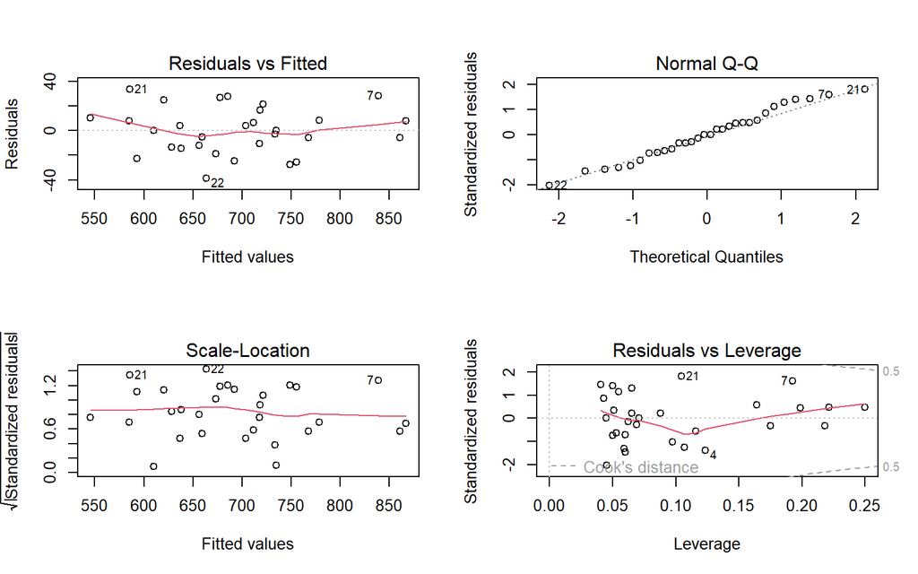

```r
par(mfrow = c(2,2))
plot(runs_forwardPval)
```

Nenhum dos modelos tem desvios severos de nossas condições necessárias para a regressão múltipla. Os métodos de diagnóstico podem ser complicados e, para realmente obter uma boa compreensão deles, será necessário um estudo mais aprofundado ou um curso de regressão.

## Por sua conta

1. Usando todas as variáveis disponíveis em nosso conjunto de dados, conduza a seleção reversa usando AIC para selecionar o melhor modelo de previsão de `wins` para uma equipe em uma única temporada. Dicas: verifique se você está usando o conjunto de dados `mlb11_wins`. Quantas variáveis estão sendo usadas para prever `wins` no modelo completo? Quais variáveis estão incluídas neste modelo final?

Primeiramente, vamos ajustar o modelo linear completo para a variável `wins`:

```r
wins_full = lm(wins ~ ., data = mlb11_wins)
```

Para realizar a seleção reversa do modelo usando o AIC como critério, usaremos novamente a função `step()`:

```r
wins_backAIC = step(wins_full, direction = "backward")
```

```
## Start:  AIC=133.92
## wins ~ runs + at_bats + hits + homeruns + bat_avg + strikeouts +
##     stolen_bases + new_onbase + new_slug + new_obs
##
##                Df Sum of Sq    RSS    AIC
## - homeruns      1     0.270 1251.6 131.93
## - hits          1     0.824 1252.2 131.94
## - bat_avg       1     4.707 1256.1 132.04
## - runs          1     5.022 1256.4 132.04
## - at_bats       1     9.741 1261.1 132.16
## - stolen_bases  1    21.592 1273.0 132.44
## <none>                      1251.4 133.92
## - new_obs       1    90.142 1341.5 134.01
## - new_slug      1   107.449 1358.8 134.40
## - new_onbase    1   113.252 1364.6 134.52
## - strikeouts    1   187.618 1439.0 136.12
##
## Step:  AIC=131.93
## wins ~ runs + at_bats + hits + bat_avg + strikeouts + stolen_bases +
##     new_onbase + new_slug + new_obs
##
##                Df Sum of Sq    RSS    AIC
## - hits          1     0.649 1252.3 129.95
## - bat_avg       1     4.480 1256.1 130.04
## - runs          1     5.682 1257.3 130.07
## - at_bats       1     9.566 1261.2 130.16
## - stolen_bases  1    30.133 1281.8 130.64
## <none>                      1251.6 131.93
## - new_obs       1    89.874 1341.5 132.01
## - new_slug      1   108.532 1360.2 132.43
## - new_onbase    1   113.059 1364.7 132.52
## - strikeouts    1   195.339 1447.0 134.28
##
## Step:  AIC=129.95
## wins ~ runs + at_bats + bat_avg + strikeouts + stolen_bases +
##     new_onbase + new_slug + new_obs
##
##                Df Sum of Sq    RSS    AIC
## - runs          1     7.139 1259.4 128.12
## - stolen_bases  1    32.173 1284.5 128.71
```

[output cut: 30 more lines]

```
## - new_onbase  1   110.625 1395.2 127.19
## - strikeouts  1   224.067 1508.6 129.53
## - at_bats     1   235.428 1520.0 129.76
## - bat_avg     1   299.052 1583.6 130.99
##
## Step:  AIC=126.68
## wins ~ at_bats + bat_avg + strikeouts + new_onbase + new_slug
##
##              Df Sum of Sq    RSS    AIC
## <none>                    1371.8 126.68
## - new_onbase  1    142.56 1514.4 127.65
## - at_bats     1    204.57 1576.4 128.85
## - strikeouts  1    223.62 1595.4 129.21
## - bat_avg     1    251.42 1623.2 129.73
## - new_slug    1    679.61 2051.4 136.75
```

```r
summary(wins_backAIC)
```

```
##
## Call:
## lm(formula = wins ~ at_bats + bat_avg + strikeouts + new_onbase +
##     new_slug, data = mlb11_wins)
##
## Residuals:
##      Min       1Q   Median       3Q      Max
## -11.4848  -4.8688   0.3299   2.2683  18.5207
##
## Coefficients:
##               Estimate Std. Error t value Pr(>|t|)
## (Intercept)  309.52337  137.51171   2.251  0.03382 *
## at_bats       -0.05254    0.02777  -1.892  0.07064 .
## bat_avg     -706.00785  336.62828  -2.097  0.04668 *
## strikeouts    -0.03467    0.01753  -1.978  0.05953 .
## new_onbase   430.03765  272.30082   1.579  0.12736
## new_slug     360.19711  104.46009   3.448  0.00209 **
## ---
## Signif. codes:  0 '***' 0.001 '**' 0.01 '*' 0.05 '.' 0.1 ' ' 1
##
## Residual standard error: 7.56 on 24 degrees of freedom
## Multiple R-squared:  0.637,  Adjusted R-squared:  0.5614
## F-statistic: 8.423 on 5 and 24 DF,  p-value: 0.000103
```

Como podemos ver, no modelo completo, 10 variáveis estão sendo usadas para prever `wins` no modelo completo. No modelo final selecionado pelo critério AIC, por outro lado, restaram 5 variáveis, as quais estão mostradas na saída do comando `summary()`, logo acima.

2. Construa um intervalo de confiança de 95% para uma das inclinações no modelo final da parte 1.

Para fazer isso, usaremos a função `confint()`, nativa do R:

```r
confint(wins_backAIC, level = 0.95)
```

```
##                     2.5 %        97.5 %
## (Intercept)  2.571314e+01 593.333587067
## at_bats     -1.098513e-01   0.004778712
## bat_avg     -1.400774e+03 -11.241230277
## strikeouts  -7.085079e-02   0.001506957
## new_onbase  -1.319636e+02 992.038918892
## new_slug     1.446021e+02 575.792148461
```

3. Conduza a seleção reversa usando $R^2_{adj}$ e, em seguida, o método do valor-p para selecionar o melhor modelo de previsão para `wins`. Algum dos modelos finais selecionados usando esses critérios corresponde ao modelo final selecionado usando seleção regressiva com AIC? Eles combinam entre si?

Primeiro, vamos selecionar o modelo usando o $R^2_{adj}$:

```r
# Step 1
df1 = data.frame(
  modelo = c("completo", "-runs", "-at_bats", "-hits", "-homeruns", "-bat_avg", "-strikeouts", "-stolen_bases", "-new_onbase", "-new_slug", "-new_obs"),
  adj_rsq = c(
    summary(lm(wins ~ . , mlb11_wins))$adj.r,
    summary(lm(wins ~ . - runs, mlb11_wins))$adj.r,
    summary(lm(wins ~ . - at_bats, mlb11_wins))$adj.r,
    summary(lm(wins ~ . - hits, mlb11_wins))$adj.r,
    summary(lm(wins ~ . - homeruns, mlb11_wins))$adj.r,
    summary(lm(wins ~ . - bat_avg, mlb11_wins))$adj.r,
    summary(lm(wins ~ . - strikeouts, mlb11_wins))$adj.r,
    summary(lm(wins ~ . - stolen_bases, mlb11_wins))$adj.r,
    summary(lm(wins ~ . - new_onbase, mlb11_wins))$adj.r,
    summary(lm(wins ~ . - new_slug, mlb11_wins))$adj.r,
    summary(lm(wins ~ . - new_obs, mlb11_wins))$adj.r
  )
)


df1 %>%
  kable() %>%
  kable_styling(
    full_width = F,
    bootstrap_options = c("striped", "hover", "condensed",
                          "responsive")
  ) %>%
  row_spec(
    which(df1$adj_rsq == max(
      c(
        summary(lm(wins ~ . , mlb11_wins))$adj.r,
        summary(lm(wins ~ . - runs, mlb11_wins))$adj.r,
        summary(lm(wins ~ . - at_bats, mlb11_wins))$adj.r,
        summary(lm(wins ~ . - hits, mlb11_wins))$adj.r,
        summary(lm(wins ~ . - homeruns, mlb11_wins))$adj.r,
        summary(lm(wins ~ . - bat_avg, mlb11_wins))$adj.r,
        summary(lm(wins ~ . - strikeouts, mlb11_wins))$adj.r,
        summary(lm(wins ~ . - stolen_bases, mlb11_wins))$adj.r,
        summary(lm(wins ~ . - new_onbase, mlb11_wins))$adj.r,
        summary(lm(wins ~ . - new_slug, mlb11_wins))$adj.r,
        summary(lm(wins ~ . - new_obs, mlb11_wins))$adj.r
      )
    )
    ),
    bold = T,
    color = "white",
    background = "green"
  )
```

| modelo | adj_rsq |
| --- | --- |
| completo | 0.4945803 |
| -runs | 0.5179243 |
| -at_bats | 0.5161135 |
| -hits | 0.5195352 |
| -homeruns | 0.5197478 |
| -bat_avg | 0.5180452 |
| -strikeouts | 0.4478616 |
| -stolen_bases | 0.5115664 |
| -new_onbase | 0.4763964 |
| -new_slug | 0.4786230 |
| -new_obs | 0.4852636 |

Como o modelo que removeu a variável `homeruns` possui o maior $R^2_{adj}$, passamos para a próxima etapa com esse modelo:

```r
# Step 2
df1 = data.frame(
  modelo = c("-homeruns", "-homeruns-runs", "-homeruns-at_bats", "-homeruns-hits", "-homeruns-bat_avg", "-homeruns-strikeouts", "-homeruns-stolen_bases", "-homeruns-new_onbase", "-homeruns-new_slug", "-homeruns-new_obs"),
  adj_rsq = c(
    summary(lm(wins ~ . - homeruns, mlb11_wins))$adj.r,
    summary(lm(wins ~ . - homeruns - runs, mlb11_wins))$adj.r,
    summary(lm(wins ~ . - homeruns - at_bats, mlb11_wins))$adj.r,
    summary(lm(wins ~ . - homeruns - hits, mlb11_wins))$adj.r,
    summary(lm(wins ~ . - homeruns - bat_avg, mlb11_wins))$adj.r,
    summary(lm(wins ~ . - homeruns - strikeouts, mlb11_wins))$adj.r,
    summary(lm(wins ~ . - homeruns - stolen_bases, mlb11_wins))$adj.r,
    summary(lm(wins ~ . - homeruns - new_onbase, mlb11_wins))$adj.r,
    summary(lm(wins ~ . - homeruns - new_slug, mlb11_wins))$adj.r,
    summary(lm(wins ~ . - homeruns - new_obs, mlb11_wins))$adj.r
  )
)


df1 %>%
  kable() %>%
  kable_styling(
    full_width = F,
    bootstrap_options = c("striped", "hover", "condensed",
                          "responsive")
  ) %>%
  row_spec(
    which(df1$adj_rsq == max(
      c(
        summary(lm(wins ~ . - homeruns, mlb11_wins))$adj.r,
        summary(lm(wins ~ . - homeruns - runs, mlb11_wins))$adj.r,
        summary(lm(wins ~ . - homeruns - at_bats, mlb11_wins))$adj.r,
        summary(lm(wins ~ . - homeruns - hits, mlb11_wins))$adj.r,
        summary(lm(wins ~ . - homeruns - bat_avg, mlb11_wins))$adj.r,
        summary(lm(wins ~ . - homeruns - strikeouts, mlb11_wins))$adj.r,
        summary(lm(wins ~ . - homeruns - stolen_bases, mlb11_wins))$adj.r,
        summary(lm(wins ~ . - homeruns - new_onbase, mlb11_wins))$adj.r,
        summary(lm(wins ~ . - homeruns - new_slug, mlb11_wins))$adj.r,
        summary(lm(wins ~ . - homeruns - new_obs, mlb11_wins))$adj.r
      )
    )
    ),
    bold = T,
    color = "white",
    background = "green"
  )
```

| modelo | adj_rsq |
| --- | --- |
| -homeruns | 0.5197478 |
| -homeruns-runs | 0.5405407 |
| -homeruns-at_bats | 0.5391213 |
| -homeruns-hits | 0.5423798 |
| -homeruns-bat_avg | 0.5409798 |
| -homeruns-strikeouts | 0.4712339 |
| -homeruns-stolen_bases | 0.5316055 |
| -homeruns-new_onbase | 0.5013018 |
| -homeruns-new_slug | 0.5029560 |
| -homeruns-new_obs | 0.5097743 |

Agora, selecionamos o modelo que removeu `homeruns` e `hits`:

```r
# Step 3
df1 = data.frame(
  modelo = c("-homeruns-hits", "-homeruns-hits-runs", "-homeruns-hits-at_bats", "-homeruns-hits-bat_avg", "-homeruns-hits-strikeouts", "-homeruns-hits-stolen_bases", "-homeruns-hits-new_onbase", "-homeruns-hits-new_slug", "-homeruns-hits-new_obs"),
  adj_rsq = c(
    summary(lm(wins ~ . - homeruns - hits, mlb11_wins))$adj.r,
    summary(lm(wins ~ . - homeruns - hits - runs, mlb11_wins))$adj.r,
    summary(lm(wins ~ . - homeruns - hits - at_bats, mlb11_wins))$adj.r,
    summary(lm(wins ~ . - homeruns - hits - bat_avg, mlb11_wins))$adj.r,
    summary(lm(wins ~ . - homeruns - hits - strikeouts, mlb11_wins))$adj.r,
    summary(lm(wins ~ . - homeruns - hits - stolen_bases, mlb11_wins))$adj.r,
    summary(lm(wins ~ . - homeruns - hits - new_onbase, mlb11_wins))$adj.r,
    summary(lm(wins ~ . - homeruns - hits - new_slug, mlb11_wins))$adj.r,
    summary(lm(wins ~ . - homeruns - hits - new_obs, mlb11_wins))$adj.r
  )
)


df1 %>%
  kable() %>%
  kable_styling(
    full_width = F,
    bootstrap_options = c("striped", "hover", "condensed",
                          "responsive")
  ) %>%
  row_spec(
    which(df1$adj_rsq == max(
      c(
        summary(lm(wins ~ . - homeruns - hits, mlb11_wins))$adj.r,
        summary(lm(wins ~ . - homeruns - hits - runs, mlb11_wins))$adj.r,
        summary(lm(wins ~ . - homeruns - hits - at_bats, mlb11_wins))$adj.r,
        summary(lm(wins ~ . - homeruns - hits - bat_avg, mlb11_wins))$adj.r,
        summary(lm(wins ~ . - homeruns - hits - strikeouts, mlb11_wins))$adj.r,
        summary(lm(wins ~ . - homeruns - hits - stolen_bases, mlb11_wins))$adj.r,
        summary(lm(wins ~ . - homeruns - hits - new_onbase, mlb11_wins))$adj.r,
        summary(lm(wins ~ . - homeruns - hits - new_slug, mlb11_wins))$adj.r,
        summary(lm(wins ~ . - homeruns - hits - new_obs, mlb11_wins))$adj.r
      )
    )
    ),
    bold = T,
    color = "white",
    background = "green"
  )
```

| modelo | adj_rsq |
| --- | --- |
| -homeruns-hits | 0.5423798 |
| -homeruns-hits-runs | 0.5606905 |
| -homeruns-hits-at_bats | 0.4816822 |
| -homeruns-hits-bat_avg | 0.4754638 |
| -homeruns-hits-strikeouts | 0.4870415 |
| -homeruns-hits-stolen_bases | 0.5519581 |
| -homeruns-hits-new_onbase | 0.5236413 |
| -homeruns-hits-new_slug | 0.5254347 |
| -homeruns-hits-new_obs | 0.5320196 |

Selecionamos então o modelo que removeu `homeruns`, `hits` e `runs`:

```r
# Step 4
df1 = data.frame(
  modelo = c("-homeruns-hits-runs", "-homeruns-hits-runs-at_bats", "-homeruns-hits-runs-bat_avg", "-homeruns-hits-runs-strikeouts", "-homeruns-hits-runs-stolen_bases", "-homeruns-hits-runs-new_onbase", "-homeruns-hits-runs-new_slug", "-homeruns-hits-runs-new_obs"),
  adj_rsq = c(
    summary(lm(wins ~ . - homeruns - hits - runs, mlb11_wins))$adj.r,
    summary(lm(wins ~ . - homeruns - hits - runs - at_bats, mlb11_wins))$adj.r,
    summary(lm(wins ~ . - homeruns - hits - runs - bat_avg, mlb11_wins))$adj.r,
    summary(lm(wins ~ . - homeruns - hits - runs - strikeouts, mlb11_wins))$adj.r,
    summary(lm(wins ~ . - homeruns - hits - runs - stolen_bases, mlb11_wins))$adj.r,
    summary(lm(wins ~ . - homeruns - hits - runs - new_onbase, mlb11_wins))$adj.r,
    summary(lm(wins ~ . - homeruns - hits - runs - new_slug, mlb11_wins))$adj.r,
    summary(lm(wins ~ . - homeruns - hits - runs - new_obs, mlb11_wins))$adj.r
  )
)


df1 %>%
  kable() %>%
  kable_styling(
    full_width = F,
    bootstrap_options = c("striped", "hover", "condensed",
                          "responsive")
  ) %>%
  row_spec(
    which(df1$adj_rsq == max(
      c(
        summary(lm(wins ~ . - homeruns - hits - runs, mlb11_wins))$adj.r,
        summary(lm(wins ~ . - homeruns - hits - runs - at_bats, mlb11_wins))$adj.r,
        summary(lm(wins ~ . - homeruns - hits - runs - bat_avg, mlb11_wins))$adj.r,
        summary(lm(wins ~ . - homeruns - hits - runs - strikeouts, mlb11_wins))$adj.r,
        summary(lm(wins ~ . - homeruns - hits - runs - stolen_bases, mlb11_wins))$adj.r,
        summary(lm(wins ~ . - homeruns - hits - runs - new_onbase, mlb11_wins))$adj.r,
        summary(lm(wins ~ . - homeruns - hits - runs - new_slug, mlb11_wins))$adj.r,
        summary(lm(wins ~ . - homeruns - hits - runs - new_obs, mlb11_wins))$adj.r
      )
    )
    ),
    bold = T,
    color = "white",
    background = "green"
  )
```

| modelo | adj_rsq |
| --- | --- |
| -homeruns-hits-runs | 0.5606905 |
| -homeruns-hits-runs-at_bats | 0.5026564 |
| -homeruns-hits-runs-bat_avg | 0.4738758 |
| -homeruns-hits-runs-strikeouts | 0.5043524 |
| -homeruns-hits-runs-stolen_bases | 0.5714049 |
| -homeruns-hits-runs-new_onbase | 0.5441635 |
| -homeruns-hits-runs-new_slug | 0.5460301 |
| -homeruns-hits-runs-new_obs | 0.5523655 |

Seguimos então com o modelo que removeu também `stolen_bases`:

```r
# Step 5
df1 = data.frame(
  modelo = c("-homeruns-hits-runs-stolen_bases", "-homeruns-hits-runs-stolen_bases-at_bats", "-homeruns-hits-runs-stolen_bases-bat_avg", "-homeruns-hits-runs-stolen_bases-strikeouts", "-homeruns-hits-runs-stolen_bases-new_onbase", "-homeruns-hits-runs-stolen_bases-new_slug", "-homeruns-hits-runs-stolen_bases-new_obs"),
  adj_rsq = c(
    summary(lm(wins ~ . - homeruns - hits - runs - stolen_bases, mlb11_wins))$adj.r,
    summary(lm(wins ~ . - homeruns - hits - runs - stolen_bases - at_bats, mlb11_wins))$adj.r,
    summary(lm(wins ~ . - homeruns - hits - runs - stolen_bases - bat_avg, mlb11_wins))$adj.r,
    summary(lm(wins ~ . - homeruns - hits - runs - stolen_bases - strikeouts, mlb11_wins))$adj.r,
    summary(lm(wins ~ . - homeruns - hits - runs - stolen_bases - new_onbase, mlb11_wins))$adj.r,
    summary(lm(wins ~ . - homeruns - hits - runs - stolen_bases - new_slug, mlb11_wins))$adj.r,
    summary(lm(wins ~ . - homeruns - hits - runs - stolen_bases - new_obs, mlb11_wins))$adj.r
  )
)


df1 %>%
  kable() %>%
  kable_styling(
    full_width = F,
    bootstrap_options = c("striped", "hover", "condensed",
                          "responsive")
  ) %>%
  row_spec(
    which(df1$adj_rsq == max(
      c(
        summary(lm(wins ~ . - homeruns - hits - runs - stolen_bases, mlb11_wins))$adj.r,
        summary(lm(wins ~ . - homeruns - hits - runs - stolen_bases - at_bats, mlb11_wins))$adj.r,
        summary(lm(wins ~ . - homeruns - hits - runs - stolen_bases - bat_avg, mlb11_wins))$adj.r,
        summary(lm(wins ~ . - homeruns - hits - runs - stolen_bases - strikeouts, mlb11_wins))$adj.r,
        summary(lm(wins ~ . - homeruns - hits - runs - stolen_bases - new_onbase, mlb11_wins))$adj.r,
        summary(lm(wins ~ . - homeruns - hits - runs - stolen_bases - new_slug, mlb11_wins))$adj.r,
        summary(lm(wins ~ . - homeruns - hits - runs - stolen_bases - new_obs, mlb11_wins))$adj.r
      )
    )
    ),
    bold = T,
    color = "white",
    background = "green"
  )
```

| modelo | adj_rsq |
| --- | --- |
| -homeruns-hits-runs-stolen_bases | 0.5714049 |
| -homeruns-hits-runs-stolen_bases-at_bats | 0.5139845 |
| -homeruns-hits-runs-stolen_bases-bat_avg | 0.4936406 |
| -homeruns-hits-runs-stolen_bases-strikeouts | 0.5176170 |
| -homeruns-hits-runs-stolen_bases-new_onbase | 0.5538905 |
| -homeruns-hits-runs-stolen_bases-new_slug | 0.5550472 |
| -homeruns-hits-runs-stolen_bases-new_obs | 0.5613608 |

como este último passo não resultou em aumento do $R^2_{adj}$, as variáveis que serão eliminadas por esse método serão `homeruns`, `hits`, `runs` e `stolen_bases`:

```r
wins_backADJr = update(wins_full, ~ . -homeruns-hits-runs-stolen_bases)
summary(wins_backADJr)
```

```
##
## Call:
## lm(formula = wins ~ at_bats + bat_avg + strikeouts + new_onbase +
##     new_slug + new_obs, data = mlb11_wins)
##
## Residuals:
##      Min       1Q   Median       3Q      Max
## -11.3025  -4.1015  -0.3745   3.3111  16.2412
##
## Coefficients:
##               Estimate Std. Error t value Pr(>|t|)
## (Intercept)  3.309e+02  1.370e+02   2.415   0.0241 *
## at_bats     -5.679e-02  2.766e-02  -2.053   0.0516 .
## bat_avg     -7.831e+02  3.384e+02  -2.314   0.0300 *
## strikeouts  -3.471e-02  1.733e-02  -2.003   0.0571 .
## new_onbase   3.690e+03  2.622e+03   1.407   0.1727
## new_slug     3.689e+03  2.665e+03   1.384   0.1796
## new_obs     -3.269e+03  2.615e+03  -1.250   0.2239
## ---
## Signif. codes:  0 '***' 0.001 '**' 0.01 '*' 0.05 '.' 0.1 ' ' 1
##
## Residual standard error: 7.473 on 23 degrees of freedom
## Multiple R-squared:  0.6601, Adjusted R-squared:  0.5714
## F-statistic: 7.444 on 6 and 23 DF,  p-value: 0.0001629
```

Finalmente, vamos fazer a seleção reversa do modelo linear para `wins` usando o critério do p-valor:

```r
ols_step_backward_p(wins_full, prem = 0.05, progress = T)
```

```
## Backward Elimination Method
## ---------------------------
##
## Candidate Terms:
##
## 1 . runs
## 2 . at_bats
## 3 . hits
## 4 . homeruns
## 5 . bat_avg
## 6 . strikeouts
## 7 . stolen_bases
## 8 . new_onbase
## 9 . new_slug
## 10 . new_obs
##
## We are eliminating variables based on p value...
##
## Variables Removed:
##
## - homeruns
## - hits
## - runs
## - stolen_bases
## - new_obs
## - new_onbase
## - bat_avg
## - strikeouts
##
## No more variables satisfy the condition of p value = 0.05
##
##
## Final Model Output
## ------------------
##
##                         Model Summary
## --------------------------------------------------------------
## R                       0.736       RMSE                8.003
## R-Squared               0.542       Coef. Var           9.884
## Adj. R-Squared          0.508       MSE                64.049
```

[output cut: 9 more lines]

```
##                Squares        DF    Mean Square      F         Sig.
## --------------------------------------------------------------------
## Regression    2049.655         2       1024.828    16.001    0.0000
## Residual      1729.312        27         64.049
## Total         3778.967        29
## --------------------------------------------------------------------
##
##                                     Parameter Estimates
## -------------------------------------------------------------------------------------------
##       model       Beta    Std. Error    Std. Beta      t        Sig       lower      upper
## -------------------------------------------------------------------------------------------
## (Intercept)    343.785       116.728                  2.945    0.007    104.279    583.290
##     at_bats     -0.074         0.024       -0.518    -3.122    0.004     -0.123     -0.025
##    new_slug    366.609        65.038        0.936     5.637    0.000    233.161    500.056
## -------------------------------------------------------------------------------------------
```

```
##
##
##                             Elimination Summary
## ----------------------------------------------------------------------------
##         Variable                      Adj.
## Step      Removed       R-Square    R-Square     C(p)       AIC        RMSE
## ----------------------------------------------------------------------------
##    1    homeruns          0.6688      0.5197    9.0041    219.0663    7.9108
##    2    hits              0.6686      0.5424    7.0139    217.0819    7.7222
##    3    runs              0.6667      0.5607    5.1223    215.2524    7.5661
##    4    stolen_bases      0.6601      0.5714    3.5040    213.8452    7.4733
##    5    new_obs            0.637      0.5614    2.8289    213.8170    7.5603
##    6    new_onbase        0.5993      0.5351    2.9935    214.7830    7.7830
##    7    bat_avg           0.5672      0.5173    2.8327    215.0915    7.9312
##    8    strikeouts        0.5424      0.5085    2.2571    214.7648    8.0030
## ----------------------------------------------------------------------------
```

Agora, vamos atualizar o modelo com as variáveis selecionadas:

```r
wins_backPval = update(
  wins_full,
  ~ . -homeruns-hits-runs-stolen_bases-new_obs-new_onbase-bat_avg-strikeouts
)
summary(wins_backPval)
```

```
##
## Call:
## lm(formula = wins ~ at_bats + new_slug, data = mlb11_wins)
##
## Residuals:
##      Min       1Q   Median       3Q      Max
## -12.6060  -4.4027  -0.0856   2.5807  26.5486
##
## Coefficients:
##              Estimate Std. Error t value Pr(>|t|)
## (Intercept) 343.78457  116.72779   2.945  0.00657 **
## at_bats      -0.07405    0.02372  -3.122  0.00425 **
## new_slug    366.60861   65.03832   5.637 5.54e-06 ***
## ---
## Signif. codes:  0 '***' 0.001 '**' 0.01 '*' 0.05 '.' 0.1 ' ' 1
##
## Residual standard error: 8.003 on 27 degrees of freedom
## Multiple R-squared:  0.5424, Adjusted R-squared:  0.5085
## F-statistic:    16 on 2 and 27 DF,  p-value: 2.611e-05
```

Os três modelos selecionados com os diferentes métodos são diferentes entre si. A menor diferença está naqueles selecionados por AIC e pelo método do $R^2_{adj}$, os quais possuem 5 e 6 variáveis preditoras, respectivamente.

4. Realize a seleção direta com os três critérios diferentes que usamos para selecionar o melhor modelo de previsão de `wins`. Eles são todos iguais?

Vamos começar usando AIC:

```r
wins_null = lm(wins ~ 1, data = mlb11_wins)
wins_forwardAIC = step(wins_null, direction = "forward", scope = formula(wins_full))
```

```
## Start:  AIC=147.08
## wins ~ 1
##
##                Df Sum of Sq    RSS    AIC
## + homeruns      1   1649.18 2129.8 131.88
## + new_slug      1   1425.43 2353.5 134.87
## + new_obs       1   1415.74 2363.2 135.00
## + runs          1   1364.10 2414.9 135.65
## + new_onbase    1   1152.63 2626.3 138.16
## + bat_avg       1    465.02 3313.9 145.14
## + hits          1    334.82 3444.1 146.30
## + strikeouts    1    297.81 3481.2 146.62
## <none>                      3779.0 147.08
## + stolen_bases  1     15.77 3763.2 148.96
## + at_bats       1     14.60 3764.4 148.96
##
## Step:  AIC=131.88
## wins ~ homeruns
##
##                Df Sum of Sq    RSS    AIC
## + at_bats       1   153.276 1976.5 131.64
## <none>                      2129.8 131.88
## + new_onbase    1   128.339 2001.5 132.01
## + strikeouts    1   109.761 2020.0 132.29
## + new_obs       1    64.573 2065.2 132.95
## + runs          1    61.401 2068.4 133.00
## + new_slug      1    28.850 2100.9 133.47
## + bat_avg       1     7.508 2122.3 133.77
## + hits          1     0.870 2128.9 133.87
## + stolen_bases  1     0.639 2129.2 133.87
##
## Step:  AIC=131.64
## wins ~ homeruns + at_bats
##
##                Df Sum of Sq    RSS    AIC
## + new_onbase    1    411.26 1565.2 126.64
## + new_obs       1    367.10 1609.4 127.47
## + strikeouts    1    312.19 1664.3 128.48
## + runs          1    309.68 1666.8 128.52
## + new_slug      1    288.57 1687.9 128.90
```

[output cut: 14 more lines]

```
## + new_obs       1     0.266 1565.0 128.63
## + bat_avg       1     0.147 1565.1 128.63
## + runs          1     0.011 1565.2 128.64
##
## Step:  AIC=126.09
## wins ~ homeruns + at_bats + new_onbase + strikeouts
##
##                Df Sum of Sq    RSS    AIC
## <none>                      1438.0 126.09
## + bat_avg       1    32.858 1405.1 127.40
## + hits          1    31.429 1406.6 127.43
## + stolen_bases  1     1.237 1436.8 128.07
## + new_obs       1     1.070 1436.9 128.07
## + runs          1     0.170 1437.8 128.09
## + new_slug      1     0.134 1437.8 128.09
```

```r
summary(wins_forwardAIC)
```

```
##
## Call:
## lm(formula = wins ~ homeruns + at_bats + new_onbase + strikeouts,
##     data = mlb11_wins)
##
## Residuals:
##      Min       1Q   Median       3Q      Max
## -14.1124  -3.9547  -0.5518   2.6519  20.8810
##
## Coefficients:
##              Estimate Std. Error t value Pr(>|t|)
## (Intercept) 357.69334  123.61509   2.894  0.00779 **
## homeruns      0.18240    0.05126   3.558  0.00153 **
## at_bats      -0.06915    0.02274  -3.040  0.00548 **
## new_onbase  325.75679  164.22009   1.984  0.05838 .
## strikeouts   -0.02336    0.01570  -1.487  0.14940
## ---
## Signif. codes:  0 '***' 0.001 '**' 0.01 '*' 0.05 '.' 0.1 ' ' 1
##
## Residual standard error: 7.584 on 25 degrees of freedom
## Multiple R-squared:  0.6195, Adjusted R-squared:  0.5586
## F-statistic: 10.17 on 4 and 25 DF,  p-value: 4.971e-05
```

Agora, vamos usar o método do $R^2_{adj}$ para seleção do modelo:

```r
# Step 1
df1 = data.frame(
  modelo = c("nulo", "+runs", "+at_bats", "+hits", "+homeruns", "+bat_avg", "+strikeouts", "+stolen_bases", "+new_onbase", "+new_slug", "+new_obs"),
  adj_rsq = c(
    summary(lm(wins ~ 1 , mlb11_wins))$adj.r,
    summary(lm(wins ~ 1 + runs, mlb11_wins))$adj.r,
    summary(lm(wins ~ 1 + at_bats, mlb11_wins))$adj.r,
    summary(lm(wins ~ 1 + hits, mlb11_wins))$adj.r,
    summary(lm(wins ~ 1 + homeruns, mlb11_wins))$adj.r,
    summary(lm(wins ~ 1 + bat_avg, mlb11_wins))$adj.r,
    summary(lm(wins ~ 1 + strikeouts, mlb11_wins))$adj.r,
    summary(lm(wins ~ 1 + stolen_bases, mlb11_wins))$adj.r,
    summary(lm(wins ~ 1 + new_onbase, mlb11_wins))$adj.r,
    summary(lm(wins ~ 1 + new_slug, mlb11_wins))$adj.r,
    summary(lm(wins ~ 1 + new_obs, mlb11_wins))$adj.r
  )
)


df1 %>%
  kable() %>%
  kable_styling(
    full_width = F,
    bootstrap_options = c("striped", "hover", "condensed",
                          "responsive")
  ) %>%
  row_spec(
    which(df1$adj_rsq == max(
      c(
        summary(lm(wins ~ 1 , mlb11_wins))$adj.r,
        summary(lm(wins ~ 1 + runs, mlb11_wins))$adj.r,
        summary(lm(wins ~ 1 + at_bats, mlb11_wins))$adj.r,
        summary(lm(wins ~ 1 + hits, mlb11_wins))$adj.r,
        summary(lm(wins ~ 1 + homeruns, mlb11_wins))$adj.r,
        summary(lm(wins ~ 1 + bat_avg, mlb11_wins))$adj.r,
        summary(lm(wins ~ 1 + strikeouts, mlb11_wins))$adj.r,
        summary(lm(wins ~ 1 + stolen_bases, mlb11_wins))$adj.r,
        summary(lm(wins ~ 1 + new_onbase, mlb11_wins))$adj.r,
        summary(lm(wins ~ 1 + new_slug, mlb11_wins))$adj.r,
        summary(lm(wins ~ 1 + new_obs, mlb11_wins))$adj.r
      )
    )
    ),
    bold = T,
    color = "white",
    background = "green"
  )
```

| modelo | adj_rsq |
| --- | --- |
| nulo | 0.0000000 |
| +runs | 0.3381487 |
| +at_bats | -0.0317129 |
| +hits | 0.0560510 |
| +homeruns | 0.4162827 |
| +bat_avg | 0.0917365 |
| +strikeouts | 0.0459079 |
| +stolen_bases | -0.0313929 |
| +new_onbase | 0.2801897 |
| +new_slug | 0.3549569 |
| +new_obs | 0.3523014 |

Selecionamos então a variável `homeruns`

```r
# Step 2
df1 = data.frame(
  modelo = c("homeruns", "homeruns+runs", "homeruns+at_bats", "homeruns+hits", "homeruns+bat_avg", "homeruns+strikeouts", "homeruns+stolen_bases", "homeruns+new_onbase", "homeruns+new_slug", "homeruns+new_obs"),
  adj_rsq = c(
    summary(lm(wins ~ homeruns, mlb11_wins))$adj.r,
    summary(lm(wins ~ homeruns + runs, mlb11_wins))$adj.r,
    summary(lm(wins ~ homeruns + at_bats, mlb11_wins))$adj.r,
    summary(lm(wins ~ homeruns + hits, mlb11_wins))$adj.r,
    summary(lm(wins ~ homeruns + bat_avg, mlb11_wins))$adj.r,
    summary(lm(wins ~ homeruns + strikeouts, mlb11_wins))$adj.r,
    summary(lm(wins ~ homeruns + stolen_bases, mlb11_wins))$adj.r,
    summary(lm(wins ~ homeruns + new_onbase, mlb11_wins))$adj.r,
    summary(lm(wins ~ homeruns + new_slug, mlb11_wins))$adj.r,
    summary(lm(wins ~ homeruns + new_obs, mlb11_wins))$adj.r
  )
)


df1 %>%
  kable() %>%
  kable_styling(
    full_width = F,
    bootstrap_options = c("striped", "hover", "condensed",
                          "responsive")
  ) %>%
  row_spec(
    which(df1$adj_rsq == max(
      c(
        summary(lm(wins ~ homeruns, mlb11_wins))$adj.r,
        summary(lm(wins ~ homeruns + runs, mlb11_wins))$adj.r,
        summary(lm(wins ~ homeruns + at_bats, mlb11_wins))$adj.r,
        summary(lm(wins ~ homeruns + hits, mlb11_wins))$adj.r,
        summary(lm(wins ~ homeruns + bat_avg, mlb11_wins))$adj.r,
        summary(lm(wins ~ homeruns + strikeouts, mlb11_wins))$adj.r,
        summary(lm(wins ~ homeruns + stolen_bases, mlb11_wins))$adj.r,
        summary(lm(wins ~ homeruns + new_onbase, mlb11_wins))$adj.r,
        summary(lm(wins ~ homeruns + new_slug, mlb11_wins))$adj.r,
        summary(lm(wins ~ homeruns + new_obs, mlb11_wins))$adj.r
      )
    )
    ),
    bold = T,
    color = "white",
    background = "green"
  )
```

| modelo | adj_rsq |
| --- | --- |
| homeruns | 0.4162827 |
| homeruns+runs | 0.4121150 |
| homeruns+at_bats | 0.4382282 |
| homeruns+hits | 0.3949107 |
| homeruns+bat_avg | 0.3967973 |
| homeruns+strikeouts | 0.4258603 |
| homeruns+stolen_bases | 0.3948451 |
| homeruns+new_onbase | 0.4311405 |
| homeruns+new_slug | 0.4028634 |
| homeruns+new_obs | 0.4130168 |

Agora, selecionamos o modelo que incluiu `homeruns` e `at_bats`:

```r
# Step 3
df1 = data.frame(
  modelo = c("homeruns+at_bats", "homeruns+at_bats+runs", "homeruns+at_bats+hits", "homeruns+at_bats+bat_avg", "homeruns+at_bats+strikeouts", "homeruns+at_bats+stolen_bases", "homeruns+at_bats+new_onbase", "homeruns+at_bats+new_slug", "homeruns+at_bats+new_obs"),
  adj_rsq = c(
    summary(lm(wins ~ homeruns + at_bats, mlb11_wins))$adj.r,
    summary(lm(wins ~ homeruns + at_bats + runs, mlb11_wins))$adj.r,
    summary(lm(wins ~ homeruns + at_bats + hits, mlb11_wins))$adj.r,
    summary(lm(wins ~ homeruns + at_bats + bat_avg, mlb11_wins))$adj.r,
    summary(lm(wins ~ homeruns + at_bats + strikeouts, mlb11_wins))$adj.r,
    summary(lm(wins ~ homeruns + at_bats + stolen_bases, mlb11_wins))$adj.r,
    summary(lm(wins ~ homeruns + at_bats + new_onbase, mlb11_wins))$adj.r,
    summary(lm(wins ~ homeruns + at_bats + new_slug, mlb11_wins))$adj.r,
    summary(lm(wins ~ homeruns + at_bats + new_obs, mlb11_wins))$adj.r
  )
)


df1 %>%
  kable() %>%
  kable_styling(
    full_width = F,
    bootstrap_options = c("striped", "hover", "condensed",
                          "responsive")
  ) %>%
  row_spec(
    which(df1$adj_rsq == max(
      c(
        summary(lm(wins ~ homeruns + at_bats, mlb11_wins))$adj.r,
        summary(lm(wins ~ homeruns + at_bats + runs, mlb11_wins))$adj.r,
        summary(lm(wins ~ homeruns + at_bats + hits, mlb11_wins))$adj.r,
        summary(lm(wins ~ homeruns + at_bats + bat_avg, mlb11_wins))$adj.r,
        summary(lm(wins ~ homeruns + at_bats + strikeouts, mlb11_wins))$adj.r,
        summary(lm(wins ~ homeruns + at_bats + stolen_bases, mlb11_wins))$adj.r,
        summary(lm(wins ~ homeruns + at_bats + new_onbase, mlb11_wins))$adj.r,
        summary(lm(wins ~ homeruns + at_bats + new_slug, mlb11_wins))$adj.r,
        summary(lm(wins ~ homeruns + at_bats + new_obs, mlb11_wins))$adj.r
      )
    )
    ),
    bold = T,
    color = "white",
    background = "green"
  )
```

| modelo | adj_rsq |
| --- | --- |
| homeruns+at_bats | 0.4382282 |
| homeruns+at_bats+runs | 0.5080261 |
| homeruns+at_bats+hits | 0.4924935 |
| homeruns+at_bats+bat_avg | 0.4946901 |
| homeruns+at_bats+strikeouts | 0.5087653 |
| homeruns+at_bats+stolen_bases | 0.4166224 |
| homeruns+at_bats+new_onbase | 0.5380063 |
| homeruns+at_bats+new_slug | 0.5017954 |
| homeruns+at_bats+new_obs | 0.5249725 |

Prosseguindo, selecionamos as variáveis `homeruns`, `at_bats` e `new_onbase`:

```r
# Step 4
df1 = data.frame(
  modelo = c("homeruns+at_bats+new_onbase", "homeruns+at_bats+new_onbase+runs", "homeruns+at_bats+new_onbase+hits", "homeruns+at_bats+new_onbase+bat_avg", "homeruns+at_bats+new_onbase+strikeouts", "homeruns+at_bats+new_onbase+stolen_bases", "homeruns+at_bats+new_onbase+new_slug", "homeruns+at_bats+new_onbase+new_obs"),
  adj_rsq = c(
    summary(lm(wins ~ homeruns + at_bats + new_onbase, mlb11_wins))$adj.r,
    summary(lm(wins ~ homeruns + at_bats + new_onbase + runs, mlb11_wins))$adj.r,
    summary(lm(wins ~ homeruns + at_bats + new_onbase + hits, mlb11_wins))$adj.r,
    summary(lm(wins ~ homeruns + at_bats + new_onbase + bat_avg, mlb11_wins))$adj.r,
    summary(lm(wins ~ homeruns + at_bats + new_onbase + strikeouts, mlb11_wins))$adj.r,
    summary(lm(wins ~ homeruns + at_bats + new_onbase + stolen_bases, mlb11_wins))$adj.r,
    summary(lm(wins ~ homeruns + at_bats + new_onbase + new_slug, mlb11_wins))$adj.r,
    summary(lm(wins ~ homeruns + at_bats + new_onbase + new_obs, mlb11_wins))$adj.r
  )
)


df1 %>%
  kable() %>%
  kable_styling(
    full_width = F,
    bootstrap_options = c("striped", "hover", "condensed",
                          "responsive")
  ) %>%
  row_spec(
    which(df1$adj_rsq == max(
      c(
        summary(lm(wins ~ homeruns + at_bats + new_onbase, mlb11_wins))$adj.r,
        summary(lm(wins ~ homeruns + at_bats + new_onbase + runs, mlb11_wins))$adj.r,
        summary(lm(wins ~ homeruns + at_bats + new_onbase + hits, mlb11_wins))$adj.r,
        summary(lm(wins ~ homeruns + at_bats + new_onbase + bat_avg, mlb11_wins))$adj.r,
        summary(lm(wins ~ homeruns + at_bats + new_onbase + strikeouts, mlb11_wins))$adj.r,
        summary(lm(wins ~ homeruns + at_bats + new_onbase + stolen_bases, mlb11_wins))$adj.r,
        summary(lm(wins ~ homeruns + at_bats + new_onbase + new_slug, mlb11_wins))$adj.r,
        summary(lm(wins ~ homeruns + at_bats + new_onbase + new_obs, mlb11_wins))$adj.r
      )
    )
    ),
    bold = T,
    color = "white",
    background = "green"
  )
```

| modelo | adj_rsq |
| --- | --- |
| homeruns+at_bats+new_onbase | 0.5380063 |
| homeruns+at_bats+new_onbase+runs | 0.5195298 |
| homeruns+at_bats+new_onbase+hits | 0.5196545 |
| homeruns+at_bats+new_onbase+bat_avg | 0.5195716 |
| homeruns+at_bats+new_onbase+strikeouts | 0.5585919 |
| homeruns+at_bats+new_onbase+stolen_bases | 0.5208152 |
| homeruns+at_bats+new_onbase+new_slug | 0.5199942 |
| homeruns+at_bats+new_onbase+new_obs | 0.5196082 |

Acrescentamos então a variável `strikeouts`:

```r
# Step 5
df1 = data.frame(
  modelo = c("homeruns+at_bats+new_onbase+strikeouts", "homeruns+at_bats+new_onbase+runs", "homeruns+at_bats+new_onbase+hits", "homeruns+at_bats+new_onbase+bat_avg", "homeruns+at_bats+new_onbase+stolen_bases", "homeruns+at_bats+new_onbase+new_slug", "homeruns+at_bats+new_onbase+new_obs"),
  adj_rsq = c(
    summary(lm(wins ~ homeruns + at_bats + new_onbase + strikeouts, mlb11_wins))$adj.r,
    summary(lm(wins ~ homeruns + at_bats + new_onbase + strikeouts + runs, mlb11_wins))$adj.r,
    summary(lm(wins ~ homeruns + at_bats + new_onbase + strikeouts + hits, mlb11_wins))$adj.r,
    summary(lm(wins ~ homeruns + at_bats + new_onbase + strikeouts + bat_avg, mlb11_wins))$adj.r,
    summary(lm(wins ~ homeruns + at_bats + new_onbase + strikeouts + stolen_bases, mlb11_wins))$adj.r,
    summary(lm(wins ~ homeruns + at_bats + new_onbase + strikeouts + new_slug, mlb11_wins))$adj.r,
    summary(lm(wins ~ homeruns + at_bats + new_onbase + strikeouts + new_obs, mlb11_wins))$adj.r
  )
)


df1 %>%
  kable() %>%
  kable_styling(
    full_width = F,
    bootstrap_options = c("striped", "hover", "condensed",
                          "responsive")
  ) %>%
  row_spec(
    which(df1$adj_rsq == max(
      c(
        summary(lm(wins ~ homeruns + at_bats + new_onbase + strikeouts, mlb11_wins))$adj.r,
        summary(lm(wins ~ homeruns + at_bats + new_onbase + strikeouts + runs, mlb11_wins))$adj.r,
        summary(lm(wins ~ homeruns + at_bats + new_onbase + strikeouts + hits, mlb11_wins))$adj.r,
        summary(lm(wins ~ homeruns + at_bats + new_onbase + strikeouts + bat_avg, mlb11_wins))$adj.r,
        summary(lm(wins ~ homeruns + at_bats + new_onbase + strikeouts + stolen_bases, mlb11_wins))$adj.r,
        summary(lm(wins ~ homeruns + at_bats + new_onbase + strikeouts + new_slug, mlb11_wins))$adj.r,
        summary(lm(wins ~ homeruns + at_bats + new_onbase + strikeouts + new_obs, mlb11_wins))$adj.r
      )
    )
    ),
    bold = T,
    color = "white",
    background = "green"
  )
```

| modelo | adj_rsq |
| --- | --- |
| homeruns+at_bats+new_onbase+strikeouts | 0.5585919 |
| homeruns+at_bats+new_onbase+runs | 0.5402542 |
| homeruns+at_bats+new_onbase+hits | 0.5502493 |
| homeruns+at_bats+new_onbase+bat_avg | 0.5507062 |
| homeruns+at_bats+new_onbase+stolen_bases | 0.5405953 |
| homeruns+at_bats+new_onbase+new_slug | 0.5402428 |
| homeruns+at_bats+new_onbase+new_obs | 0.5405421 |

Como nenhum dos modelos que adicionou uma quinta variável possui um maior valor de $R^2_{adj}$, paramos a seleção. O modelo final de acordo com esse critério de seleção será:

```r
wins_forwardADJr = update(wins_null, ~ . + homeruns + at_bats + new_onbase + strikeouts)
summary(wins_forwardADJr)
```

```
##
## Call:
## lm(formula = wins ~ homeruns + at_bats + new_onbase + strikeouts,
##     data = mlb11_wins)
##
## Residuals:
##      Min       1Q   Median       3Q      Max
## -14.1124  -3.9547  -0.5518   2.6519  20.8810
##
## Coefficients:
##              Estimate Std. Error t value Pr(>|t|)
## (Intercept) 357.69334  123.61509   2.894  0.00779 **
## homeruns      0.18240    0.05126   3.558  0.00153 **
## at_bats      -0.06915    0.02274  -3.040  0.00548 **
## new_onbase  325.75679  164.22009   1.984  0.05838 .
## strikeouts   -0.02336    0.01570  -1.487  0.14940
## ---
## Signif. codes:  0 '***' 0.001 '**' 0.01 '*' 0.05 '.' 0.1 ' ' 1
##
## Residual standard error: 7.584 on 25 degrees of freedom
## Multiple R-squared:  0.6195, Adjusted R-squared:  0.5586
## F-statistic: 10.17 on 4 and 25 DF,  p-value: 4.971e-05
```

Por fim, fazemos a seleção de variáveis usando o método do p-valor:

```r
ols_step_forward_p(wins_full, penter = 0.05, progress = T)
```

```
## Forward Selection Method
## ---------------------------
##
## Candidate Terms:
##
## 1. runs
## 2. at_bats
## 3. hits
## 4. homeruns
## 5. bat_avg
## 6. strikeouts
## 7. stolen_bases
## 8. new_onbase
## 9. new_slug
## 10. new_obs
##
## We are selecting variables based on p value...
##
## Variables Entered:
##
## - homeruns
##
## No more variables to be added.
##
## Final Model Output
## ------------------
##
##                         Model Summary
## --------------------------------------------------------------
## R                       0.661       RMSE                8.721
## R-Squared               0.436       Coef. Var          10.772
## Adj. R-Squared          0.416       MSE                76.064
## Pred R-Squared          0.362       MAE                 6.789
## --------------------------------------------------------------
##  RMSE: Root Mean Square Error
##  MSE: Mean Square Error
##  MAE: Mean Absolute Error
##
##                                ANOVA
## --------------------------------------------------------------------
##                 Sum of
##                Squares        DF    Mean Square      F         Sig.
## --------------------------------------------------------------------
## Regression    1649.182         1       1649.182    21.682     1e-04
## Residual      2129.785        28         76.064
## Total         3778.967        29
## --------------------------------------------------------------------
##
##                                   Parameter Estimates
## ---------------------------------------------------------------------------------------
##       model      Beta    Std. Error    Std. Beta      t       Sig      lower     upper
## ---------------------------------------------------------------------------------------
## (Intercept)    48.814         7.086                 6.888    0.000    34.298    63.330
##    homeruns     0.212         0.046        0.661    4.656    0.000     0.119     0.305
## ---------------------------------------------------------------------------------------
```

```
##
##                            Selection Summary
## ------------------------------------------------------------------------
##         Variable                  Adj.
## Step    Entered     R-Square    R-Square     C(p)       AIC        RMSE
## ------------------------------------------------------------------------
##    1    homeruns      0.4364      0.4163    6.3377    219.0137    8.7215
## ------------------------------------------------------------------------
```

Atualizamos então o modelo selecionado:

```r
wins_forwardPval = update(wins_null, ~ . + homeruns)
summary(wins_forwardPval)
```

```
##
## Call:
## lm(formula = wins ~ homeruns, data = mlb11_wins)
##
## Residuals:
##      Min       1Q   Median       3Q      Max
## -20.2874  -6.7083   0.7708   5.6292  20.7649
##
## Coefficients:
##             Estimate Std. Error t value Pr(>|t|)
## (Intercept) 48.81397    7.08635   6.888 1.74e-07 ***
## homeruns     0.21190    0.04551   4.656 7.09e-05 ***
## ---
## Signif. codes:  0 '***' 0.001 '**' 0.01 '*' 0.05 '.' 0.1 ' ' 1
##
## Residual standard error: 8.721 on 28 degrees of freedom
## Multiple R-squared:  0.4364, Adjusted R-squared:  0.4163
## F-statistic: 21.68 on 1 and 28 DF,  p-value: 7.094e-05
```